# Project Report

Explore Statistical Methods to Predict Heart Arrhythmia

Hari Nath Bingi

29/05/2020

## **Overview of the problem**

Diagnosis of a heart arrhythmia involves measuring the heart activity for irregular heart beat using Electrocardiogram (ECG) and then analysing the recorded data. These parameters coupled with patient information can then be used by doctors to identify arrhythmia and its category.

Some challenges in identifying arrhythmia are:

- Many of the current algorithms are rule based implementation but the cardio log’s classification is different and better.
- Impossible for a doctor to identify minute steeps and irregularities due to the high number of parameters (i.e. > 270) involved.
- **90% of clinical alarms in intensive care units might be false**. This high percentage negatively impacts both patients and clinical staff. The alarm overload might also lead to desensitization and could result in true alarms being ignored.

Hence we aim to create a classification model which will draw conclusions from the cardio log’s data as a gold standard and will distinguish between the presence and absence of cardiac arrhythmia and to classify it in one of the 16 groups from ECG data of new patients. This will help in achieving the below.

- Reducing false alarms which in turn helps clinical staff to focus on the attention required areas.
- Accurate detection to expedite patient’s treatment.

## **Dataset**

The data has been captured as a part of study by H. Altay Guvenir and is available in [uci](http://archive.ics.uci.edu/ml/datasets/Arrhythmia) Machine Learning repository.

```r
arrhythmia_df = read.csv("arrhythmia.data",header=FALSE,na.strings=c("?"))
```

Our data has 452 observations and 279 features for each observation.

| No. of Features | Type | Example Features |
| --- | --- | --- |
| 110 | Categorical | Sex, Rag_R_Nom, Diph_R_Nom, Rag_P_Nom, Diph_P_Nom, Rag_T_Nom |
| 169 | Numeric | Age, Height, Weight, QRS_Dur |

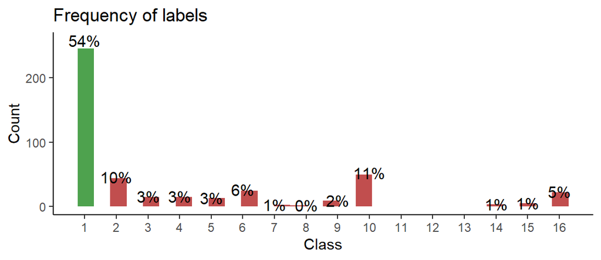

The above histogram describes the distribution of labels. Class 01 refers to ‘normal’ which constitute 54% of our data. The contribution for various classes of arrhythmia is less, for class 11,12,13 it is 0. The code for this is available in appendix.

| Class Label | Class Description |
| --- | --- |
| 1 | Normal |
| 2 | Ischemic changes (Coronary Artery Disease) |
| 3 | Old Anterior Myocardial Infarction |
| 4 | Old Inferior Myocardial Infarction |
| 5 | Sinus tachycardy |
| 6 | Sinus bradycardy |
| 7 | Ventricular Premature Contraction (PVC) |
| 8 | Supraventricular Premature Contraction |
| 9 | Left bundle branch block |
| 10 | Right bundle branch block |
| 11 | 1 degree AtrioVentricular block |
| 12 | 2 degree AV block |
| 13 | 3 degree AV block |
| 14 | Left ventricule hypertrophy |
| 15 | Atrial Fibrillation or Flutter |
| 16 | Others |

### **Missing Values**

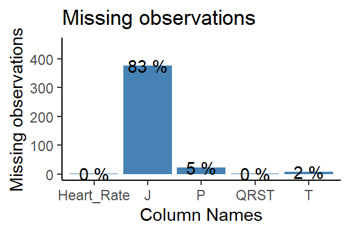

From the above bar plot it is clear that we have missing values in 5 columns with column J having missing values for around 83% of observations. The code for this is available in appendix.

### **Challenges and Mitigation**

| Challenge | Mitigation |
| --- | --- |
| High number of features as compared to limited number of training data points | We will try dimensionality reduction using PCA and feature subset using forward stepwise selection and compare classifier results to determine the best approach. |
| Missing values for numerical data columns | We will use various imputation techniques in the next section. |
| Heavily biased towards the normal cases | We will perform over sampling to balance the classes, we will only perform it on training data to avoid information leakage. |

## **Data Cleaning**

### **Handling Missing Values**

[output not shown]

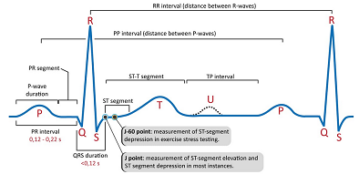

ECG Waveform

Table explaining missing Heart_Rate data

```r
 #Two records for a male patient, age 75, height 190, weight 80 and Heart_Rate for one is missing
dplyr::filter(arrhythmia_df_nolabels[,c("Age","Sex","Height","Weight","Heart_Rate")],(Age==75 & Sex == 0 & Height== 190 & Weight == 80))
```

| Age | Sex | Height | Weight | Heart_Rate |
| --- | --- | --- | --- | --- |
| 75 | 0 | 190 | 80 | 63 |
| 75 | 0 | 190 | 80 | NA |

| Age <int> | Sex <int> | Height <int> | Weight <int> | Heart_Rate <int> |
| --- | --- | --- | --- | --- |
| 75 | 0 | 190 | 80 | 63 |
| 75 | 0 | 190 | 80 | NA |

2 rows

Data cleanup actions are perfomed below.

```r
processed_arrhythmia_df_nolabels = arrhythmia_df_nolabels[,-which(names(arrhythmia_df_nolabels) %in% c("J"))] #Drop column J
processed_arrhythmia_df_nolabels$Heart_Rate[is.na(processed_arrhythmia_df_nolabels$Heart_Rate)] = 63 #Value from other record of similar age,sex,weight and height
processed_arrhythmia_df_nolabels$QRST = Hmisc::impute(processed_arrhythmia_df_nolabels$QRST, median)  #Impute QRST with mediam
library(VIM)
processed_arrhythmia_df_nolabels = kNN(processed_arrhythmia_df_nolabels,
                                       variable = c("P", "T"),
                                       k = 6) #knn impute column P,T
processed_arrhythmia_df_nolabels = processed_arrhythmia_df_nolabels[,-which(names(processed_arrhythmia_df_nolabels) %in% c("P_imp", "T_imp"))]
```

### **Outlier Examination**

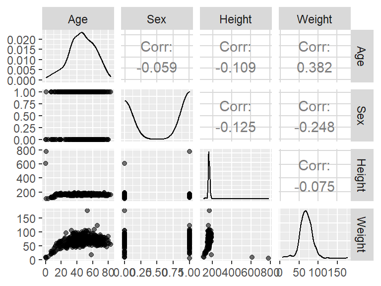

```r
library(GGally)
ggpairs(arrhythmia_df_nolabels[,c('Age', 'Sex', 'Height', 'Weight')], aes(alpha = 0.8))
```

Examining the pair wise plots for height and weight i.e. the 2 left bottom ones indicate there are some outliers in Height and Weight attributes and hence will examine them via boxplots. The code for box plot is in the appendix.

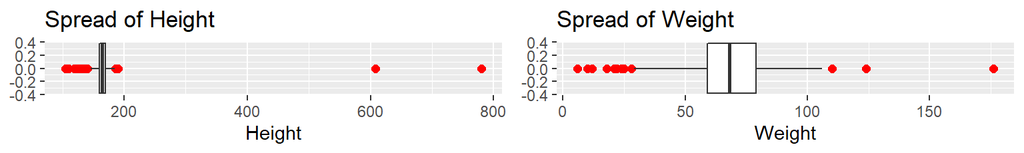

| Column | Outliers | Action Plan |
| --- | --- | --- |
| Height | 2 observation more than 600 | does not seem realistic for height more than 600 centimetres and hence I have substituted them with median of remaining observations. |
| Weight | 1 observation around 160 | 160 kilograms seems to be realistic and hence I have taken no action. |

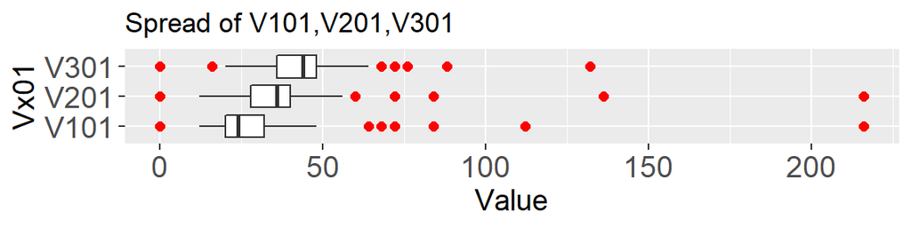

```r
processed_arrhythmia_df_nolabels$Height[which(processed_arrhythmia_df_nolabels$Height > 600)] = median(processed_arrhythmia_df_nolabels$Height[-which(processed_arrhythmia_df_nolabels$Height > 600)])
```

V101, V201,V301 indicates some outliers and there seems to be a pattern i.e. one highest value for all. The code for this is available in appendix. Hence examining the highest value of V101.

```r
arrhythmia_df[arrhythmia_df$V101 > 200,c("V101","V201","V301","class")]
```

|  | V101 | V201 | V301 | class |
| --- | --- | --- | --- | --- |
| 298 | 216 | 216 | 132 | 10 |

|  | V101 <int> | V201 <int> | V301 <int> | class <int> |
| --- | --- | --- | --- | --- |
| 298 | 216 | 216 | 132 | 10 |

1 row

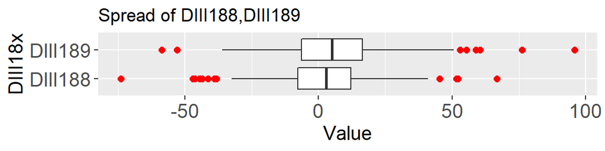

DIII188, DIII189 indicates some outliers and there seems to be a pattern i.e. one highest value for all. Hence examining the highest value of DIII188.

```r
arrhythmia_df[arrhythmia_df$DIII188 > 60,c("DIII188","DIII189","class")]
```

|  | DIII188 | DIII189 | class |
| --- | --- | --- | --- |
| 6 | 66.7 | 95.8 | 14 |

|  | DIII188 <dbl> | DIII189 <dbl> | class <int> |  |
| --- | --- | --- | --- | --- |
| 6 | 66.7 | 95.8 | 14 |  |

1 row

It looks like outlier of DIII188, DIII189 belong to same data point and to a rare class of arrhythmia i.e. class 14. As they belong a rare class and hence they do not seem to fit with others but these are not outliers.

Similar features have been examined in the same manner i.e. by using side by side box plots. The code for the same is available in appendix.

### **Identify correlated features**

#### Identifying continuous ECG correlated features:

```r
cormatrix_res <- cor(processed_arrhythmia_df_nolabels[, nonzero_var]) #Creating a correlation matrix for all continous features
x1 = y1 = c()
for (i in seq(nrow(cormatrix_res)))
{
  for (j in seq(ncol(cormatrix_res)))
  {
    if (cormatrix_res[i, j] > 0.9 & i != j) #Identifying features which have a  correlation of more than 0.9
    {
      x1 = c(x1, rownames(cormatrix_res)[i])  #Rowname, colname of the matrix include the feature names
      y1 = c(y1, colnames(cormatrix_res)[j])
    }
  }
}
corelationcols = data.frame(x1, y1) #Creating a data frame
related_numerical_cols = corelationcols[!duplicated(t(apply(corelationcols, 1, sort))), ] #Removing duplicates
related_numerical_cols$x1 = as.character(related_numerical_cols$x1)
related_numerical_cols$y1 = as.character(related_numerical_cols$y1)
colums_to_drop = related_numerical_cols$y1 #Saving the correlated features for future use
```

My analysis revealed that the below continuous variables are correlated and hence visualizing. The code for this visualization is available in appendix

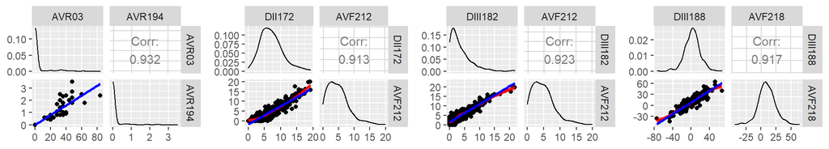

The bottom left of each graph shows the points of the respective columns and a smotting line to indicate they are related. We also have correlation described in all plot as > 0.9. Hence we can drop these columns i.e. AVR194, AVF212, AVF218.

#### Identifying categorical ECG correlated parameters using Goodman and Kruskal’s Tau measure:

```r
library("GoodmanKruskal")
subset_arrhythmia_df <-   subset(processed_arrhythmia_df_nolabels, select = categorical_columns)
GKmatrix1 <- GKtauDataframe(subset_arrhythmia_df)  #Calculating Goodman and Kruskal’s Tau measure for categorical features
x2 = y2 = c()
for (i in seq(nrow(GKmatrix1)))
{
  for (j in seq(ncol(GKmatrix1)))
  {
    if (!is.na(GKmatrix1[i, j]))
    {
      if (GKmatrix1[i, j] > 0.9 & i != j) #Identifying features which have a forward association of more than 0.9
      {
        x2 = c(x2, rownames(GKmatrix1)[i]) #Rowname, colname of the matrix include the feature names
        y2 = c(y2, colnames(GKmatrix1)[j])
      }
    }
  }
}
corelationcols2 = data.frame(x2, y2) #Storing the values in a data frame
related_cat_cols = corelationcols2[!duplicated(t(apply(corelationcols2, 1, sort))), ] #Removing duplicates tuples
```

| Column X | R’_Wave | DII04 | DII04 | AVR04 | AVF04 | AVF04 | V303 | V303 | V303 | V304 | V404 | V603 | DII174 | DII175 | DIII185 | AVF215 | V1225 | V2235 | V3244 | V3244 | V3244 |
| --- | --- | --- | --- | --- | --- | --- | --- | --- | --- | --- | --- | --- | --- | --- | --- | --- | --- | --- | --- | --- | --- |
| Column Y | R_Prime_Wave | AVL11 | DII175 | AVR195 | AVL11 | AVF215 | V304 | V3244 | V3245 | V3245 | V4255 | V6274 | AVL11 | AVL11 | DIII04 | AVL11 | V104 | V204 | AVL08 | V304 | V3245 |
| Tau(x,y) | 1.000 | 1.000 | 1.000 | 1.000 | 1.000 | 1.000 | 1.000 | 0.916 | 1.000 | 1.000 | 1.000 | 1.000 | 1.000 | 1.000 | 1.000 | 1.000 | 1.000 | 1.000 | 1.000 | 1.000 | 1.000 |

```
## [1] "Hence these columns can be dropped - R_Prime_Wave, AVL11, DII175, AVR195, AVF215, V304, V3244, V3245, V4255, V6274, DIII04, V104, V204, AVL08"
```

## **Evaluation metric**

**We will use macro averaged f1-score and macro averaged recall as metric to evaluate our model**

We will calculate macro averaged f1 as a simple arithmetic mean of our per-class F1-scores.

As the data is highly skewed towards class 01 and we want our classification models to classify all labels with equal importance we are choosing macro averaged f1. We will also use macro averaged recall as a guiding factor to ensure our model is able to classify high number of relevant classes.

We have defined a function in the below code to calculate macro avergaed f1, macro averaged recall.

```r
calcF1Scores = function(actual, predicted) {
  actual = as.numeric(actual)
  predicted = as.numeric(predicted)
  df = data.frame(actual = actual, predicted = predicted) #Creare a dataframe for actual and predicted for eacy comparison
  fone = recall = c()
  for (i in seq(min(actual), max(actual))) {  #Calculate fone and recall for every class
    tp = nrow(df[df$predicted == i & df$actual == i, ])
    fp = nrow(df[df$predicted == i & df$actual != i, ])
    fn = nrow(df[df$predicted != i & df$actual == i, ])
    #Calculate precision recall and f1
    PR = tp / (tp + fp)
    RE = tp / (tp + fn)
    f1 = (2 * PR * RE) / (PR + RE)
    #Handle some exception scenarios
    if (tp == fp & fp == fn & fn == 0)
    {
      PR = 1
      RE = 1
      f1 = 1
    }
    else if (tp == fp & fp == 0)
    {
      PR = 1
      RE = tp / (tp + fn)
      f1 = (2 * PR * RE) / (PR + RE)

    } else if (tp == 0)
    {
      PR = 0
      RE = 0
      f1 = 0
    }
    fone = c(fone, f1)
    recall = c(recall, RE)
  }
  return(list(mean(fone), mean(recall))) #Avergae values of all classes to calculate macro f1
}
```

## **Dimension Reduction**

### **Principal Component Analysis**

I have performed PCA on the dataset keeping correlated columns and on the dataset without keeping correlated columns. The code for PCA is in the appendix.

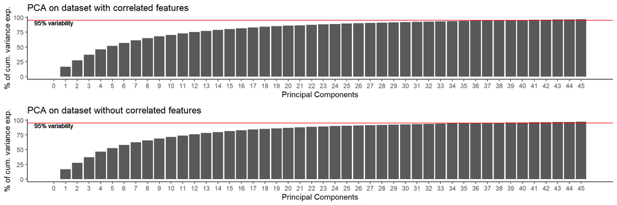

We will have to use at least 39 principal components for dataset with correlated features and 36 principal compoenets for datatset without correlated features as they explain 95% variability. It seems that dropping the correlated features did not help with principal component analysis. This principal component analysis is performed on the entire data and is only for our evaluation. We will perform principal component analysis only on training data set while building classifiers. The code of cumulative variance plot is in the appendix.

### **Feature subset**

I have performed stepwise forward selection as below:

The below is the code for knn feature subset, the code for other classifier subset is in the appendix.

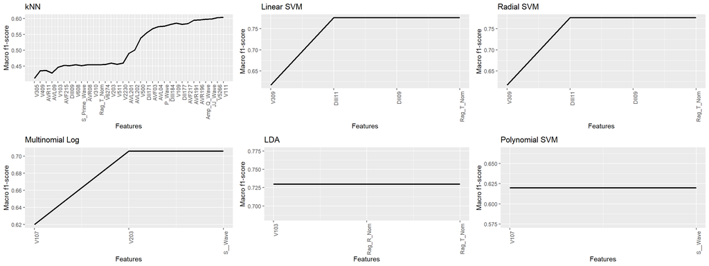

```r
library(ROSE) #ROSE package for oversampling
selectFeature <-   #This function will return the feature with best macro f1-score
  function(train, test, cls.train, cls.test, features) {
    ## identify a feature to be selected
    current.best.fone <- -Inf
    selected.i <- NULL
    for (i in 1:ncol(train)) {
      current.f <- colnames(train)[i]
      if (!current.f %in% features) { #Verify if the feature is already in considered in the list
        #Create dataframe for classifiers to be used
        subfeatures_df_train = data.frame(class = cls.train)
        subfeatures_df_test = data.frame(class = cls.test)
        allcols = c(features, current.f)
        for (eachcol in allcols)
        {
          subfeatures_df_train[, eachcol] = train[, eachcol]
          subfeatures_df_test[, eachcol] = test[, eachcol]
        }

        #Oversample the training data to balance minor classes
        oversampled_df = subfeatures_df_train
        all_exis_classes  = sort(unique(arrhythmia_labels))
        for (each_minor_class in all_exis_classes[!all_exis_classes %in% 1]) #ovun.sample only works on dataframe with 2 classes and hence the loop over all minor classes
        {
          testdf = subset(oversampled_df, class == each_minor_class | class == 1)
          balanceddata <- ovun.sample(class ~ .,data = get("testdf", sys.frame(1)),method = "over",p = 0.5)$data  #Get balanced data
          oversampled_df = rbind(  #only adding the oversampled data of minor class and not considering the data of class 1
            subset(balanceddata, class != 1),
            subset(oversampled_df, class != each_minor_class)
          )}

        flag <- TRUE
        tryCatch({ #sometimes knn throws "too many ties" for some variables and hence catching to proceed to test next feature
          preds = class::knn(oversampled_df[, -which(colnames(oversampled_df) %in% c("class")), drop = FALSE],subfeatures_df_test[, -which(colnames(subfeatures_df_test) %in% c("class")), drop =FALSE],oversampled_df[, "class"])
        }, error = function(e) {
          flag <<- FALSE
        })

        if (!flag) { next} #Iterate over next feature in case knn throws an error like "too many ties"

        f1score <- calcF1Scores(as.numeric(levels(preds))[preds], cls.test) #Calculate macro f1-score
        test.fone = round(f1score[[1]], 3)
        if (test.fone > current.best.fone) { #Save the feature with best macro f1
          current.best.fone <- test.fone
          selected.i <- colnames(train)[i]
        }
      }
    }
    return(list(selected.i, current.best.fone))  #Return feature and fone score for plotting
  }

library(caret)
set.seed(1)
inTrain <- createDataPartition(arrhythmia_labels, p = .6)[[1]] #Split data into training and validation
allFeatures <- colnames(processed_arrhythmia_df_nolabels)

train <- processed_arrhythmia_df_nolabels[inTrain, ]
test  <- processed_arrhythmia_df_nolabels[-inTrain, ]
cls.train <- arrhythmia_labels[inTrain]
cls.test <- arrhythmia_labels[-inTrain]
features <- NULL
fone_scores = NULL

#Iterating 100 times to find best 100 features
for (j in 1:100) {
  featureoutput <- selectFeature(train, test, cls.train, cls.test, features)
  features <- c(features, featureoutput[[1]])
  fone_scores = c(fone_scores, featureoutput[[2]])
}
knn_featuresubset_metrics = data.frame(Features=features,macrof1=fone_scores,index=seq(1:length(features))) #Dataframe to be used for plotting
```

We could then conclude the below as best features for the respective classifiers.

[output not shown]

## **Approach for classification**

We will try kNN, LDA, Multinomial Log, Linear SVM, Polynomial SVM, Radial SVM in 3 different approaches via cross validation.

### **Approach 1**

1. Split the dataset with correlated features into 10 folds.
2. For every fold, consider one fold as a validation data set and the remaining as training data set.
3. Perform PCA on the training data set.
4. Identify minimum number of principal components i.e. ‘p’ to explain 95% variability, in most cases it is 39.
5. Oversample ‘p’ principal components to balance classes using ROSE package.
6. Perform kNN, LDA, Multinomial Log, Linear SVM, Polynomial SVM, Radial SVM on the ‘p’ principal components of training data.
7. Apply training PCA on the validation data set.
8. Select ‘p’ principal components of the validation data set.
9. Calculate macro weight f1 for every classifier on the validation data set principal components.
10. Repeat from step 2 for all the folds.
11. Average macro weighted f1-score of all folds to achieve one macro weighted f1 for each classifier.

The below is the code for approach 1.

```r
set.seed(1)
fold <- createFolds(arrhythmia_labels, k = 10) #Create 10-fold cross-validation

#Variables to hold f1 score and recall for every hold
tmpf1knn = tmpf1linsvm = tmpf1ploy = tmpf1radc = tmpf1lda = tmpf1log = c()
tmprecaknn = tmprecalinsvm = tmprecaploy = tmprecaradc = tmprecalda = tmprecalog = c()

for (i in 1:length(fold)) {

  arrhythmia.pca <-prcomp(processed_arrhythmia_df_nolabels[-fold[[i]], ]) #Apply PCA on training set

  #Calculate cum variance
  tot.var <- sum(arrhythmia.pca$sdev ^ 2)
  var.explained <- data.frame(pc = seq(1:ncol(processed_arrhythmia_df_nolabels[-fold[[i]], ])),
               var.explained  = arrhythmia.pca$sdev ^ 2 / tot.var)
  cum_var.explained = c()
  for (u in seq(nrow(var.explained)))
  {
    cum_var.explained =  c(cum_var.explained, sum(var.explained[1:u, 2]) * 100)
  }

  pctouse = min(which(cum_var.explained > 95)) #identify number of PCs that explain 95% variability
  #Oversample minor classes of training Principal components
  oversampled_df = data.frame(arrhythmia.pca$x[, 1:pctouse])
  oversampled_df$class = arrhythmia_labels[-fold[[i]]]
  all_exis_classes  = sort(unique(arrhythmia_labels))
  for (eachminroclass in all_exis_classes[!all_exis_classes %in% 1])
  {
    balanceddata <- ovun.sample(class ~ .,data = subset(oversampled_df, class == eachminroclass | class == 1),method = "over",p = 0.5)$data
    oversampled_df = rbind(subset(balanceddata, class != 1),
                           subset(oversampled_df, class != eachminroclass))
  }
  oversampled_df <- oversampled_df[sample(nrow(oversampled_df)), ]  #Shuffling rows

#apply PCA on validation dataset
  arrhythmia.pcatest = predict(arrhythmia.pca, processed_arrhythmia_df_nolabels[fold[[i]], ])

 #Training on different classfiers and calculate validation f1-score
  preds <- knn(oversampled_df[, -which(colnames(oversampled_df) %in% c("class")), drop =FALSE],data.frame(arrhythmia.pcatest[, 1:pctouse]),oversampled_df$class)
  f1score <- calcF1Scores(as.numeric(levels(preds))[preds], arrhythmia_labels[fold[[i]]]) #Calculating validation macro f1-score
  tmpf1knn = c(tmpf1knn, f1score[[1]])
  tmprecaknn = c(tmprecaknn, f1score[[2]])

  linsvm.model1 <- svm(x = oversampled_df[, -which(colnames(oversampled_df) %in% c("class")), drop =FALSE],y = oversampled_df$class,kernel = "linear",type = "C-classification")
  preds <- predict(linsvm.model1, newdata = data.frame(arrhythmia.pcatest[, 1:pctouse]))
  f1score <- calcF1Scores(as.numeric(levels(preds))[preds], arrhythmia_labels[fold[[i]]])
  tmpf1linsvm = c(tmpf1linsvm, f1score[[1]])
  tmprecalinsvm = c(tmprecalinsvm, f1score[[2]])

  polysvm.model1 <- svm(x = oversampled_df[, -which(colnames(oversampled_df) %in% c("class")), drop =FALSE],y = oversampled_df$class,kernel = "polynomial",type = "C-classification")
  preds <- predict(polysvm.model1, newdata = data.frame(arrhythmia.pcatest[, 1:pctouse]))
  f1score <- calcF1Scores(as.numeric(levels(preds))[preds], arrhythmia_labels[fold[[i]]])
  tmpf1ploy = c(tmpf1ploy, f1score[[1]])
  tmprecaploy = c(tmprecaploy, f1score[[2]])

  radsvm.model1 <- svm(x = oversampled_df[, -which(colnames(oversampled_df) %in% c("class")), drop =FALSE],y = oversampled_df$class,kernel = "radial",type = "C-classification")
  preds <- predict(radsvm.model1, newdata = data.frame(arrhythmia.pcatest[, 1:pctouse]))
  f1score <- calcF1Scores(as.numeric(levels(preds))[preds], arrhythmia_labels[fold[[i]]])
  tmpf1radc = c(tmpf1radc, f1score[[1]])
  tmprecaradc = c(tmprecaradc, f1score[[2]])

  lda.model <- MASS::lda(class ~ ., data = oversampled_df)
  preds = predict(lda.model, newdata = data.frame(arrhythmia.pcatest[, 1:pctouse]))$class
  f1score <- calcF1Scores(as.numeric(levels(preds))[preds], arrhythmia_labels[fold[[i]]])
  tmpf1lda = c(tmpf1lda, f1score[[1]])
  tmprecalda = c(tmprecalda, f1score[[2]])

  multinomlogmodel <- multinom(class ~ ., data = oversampled_df, trace = FALSE)
  preds = predict(multinomlogmodel, newdata = data.frame(arrhythmia.pcatest[, 1:pctouse]))
  f1score <- calcF1Scores(as.numeric(levels(preds))[preds], arrhythmia_labels[fold[[i]]])
  tmpf1log = c(tmpf1log, f1score[[1]])
  tmprecalog = c(tmprecalog, f1score[[2]])
}

fone.val = c(mean(tmpf1log),mean(tmpf1lda),mean(tmpf1knn),mean(tmpf1linsvm),mean(tmpf1ploy),mean(tmpf1radc))
recall.val = c(mean(tmprecalog),mean(tmprecalda),mean(tmprecaknn),mean(tmprecalinsvm),mean(tmprecaploy),mean(tmprecaradc))

#Store values for line plot
plot_df95pca = data.frame(index = seq(1:6),fone = fone.val,recall = recall.val,algo = c("Multinomial Log","LDA","kNN","Linear SVM","Polynomial SVM","Radial SVM"))
#Store values for box plot
boxplot_df_pca95 = data.frame("Values" = c(tmprecalog,tmprecalda,tmprecaknn,tmprecalinsvm,tmprecaploy,tmprecaradc,tmpf1log,tmpf1lda,tmpf1knn,tmpf1linsvm,tmpf1ploy, tmpf1radc),"Classifiers" = rep(rep(c("Multinomial Log","LDA","kNN","Linear SVM","Polynomial SVM","Radial SVM"),each = 10), times = 2),"Metric" = rep(c("Macro Sensitivity", "Macro f1-score"), each = 60))
```

### **Approach 2**

This will be same as approach 1, but with dataset excluding correlated features. The code for this is in appendix.

### **Approach 3**

1. Split the dataset with correlated features into 10 folds.
2. For every fold, consider one fold as a validation data set and the remaining as training data set.
3. Oversample training data set to balance classes.
4. Select the best features (as described in above section) subset of oversampled training data respectively for every classifier.
5. Perform kNN, LDA, Multinomial Log, Linear SVM, Polynomial SVM, Radial SVM.
6. Calculate macro weight f1 for every classifier on the best features subset of validation data sets for every classifier respectively.
7. Repeat from step 2 for all the folds.
8. Average macro weighted f1-score of all folds to achieve one macro weighted f1 for each classifier.

The below is the code for the same.

```r
fold <- createFolds(arrhythmia_labels, k = 10)
# apply 10-fold cross-validation
tmp4f1knn = tmp4f1linsvm = tmp4f1ploy = tmp4f1radc = tmp4f1lda = tmp4f1log = c()
tmp4recaknn = tmp4recalinsvm = tmp4recaploy = tmp4recaradc = tmp4recalda = tmp4recalog = c()

for (i in 1:length(fold)) {
  # Oversample training data
  oversampled_df = processed_arrhythmia_df_nolabels[-fold[[i]], ]
  oversampled_df$class = arrhythmia_labels[-fold[[i]]]
  all_exis_classes  = sort(unique(arrhythmia_labels))
  for (eachminroclass in all_exis_classes[!all_exis_classes %in% 1]) #looping as ovun.sample only support 2 classes to be balances in once
  {
  balanceddata <- ovun.sample(class ~ .,data = subset(oversampled_df, class == eachminroclass | class == 1),method = "over",p = 0.5)$data
  oversampled_df = rbind(subset(balanceddata, class != 1),
                           subset(oversampled_df, class != eachminroclass))
  }
 oversampled_df <- oversampled_df[sample(nrow(oversampled_df)), ]  #Shuffling rows

 knnfeatures = c("V305","V409","AVR11","AVL09","V103","AVF215","DIII09","V608","S_Prime_Wave","AVR08","V310","Rag_T_Nom","V6274","V203","V511","V2230","AVL201","AVL202","V500","DII171","AVF03","AVL04","P_Wave","DIII184","V109","DII177","AVF217","AVR191","AVR196","Amp_Q_Wave","JJ_Wave","V5266","V111")
 linsvmfeatures = c("V309", "DIII11")
 polysvmfeatures =   c("V107")
 radsvmfeatures = c("V309", "DIII11")
  ldafeatures = c("V103")
  multilogfeatures = c("V107", "V203")

  preds <- knn(oversampled_df[, knnfeatures, drop = FALSE], processed_arrhythmia_df_nolabels[fold[[i]], knnfeatures],oversampled_df$class)
  f1score <- calcF1Scores(as.numeric(levels(preds))[preds], arrhythmia_labels[fold[[i]]])
  tmp4f1knn = c(tmp4f1knn, f1score[[1]])
  tmp4recaknn = c(tmp4recaknn, f1score[[2]])

  linsvm.model1 <- svm(x = oversampled_df[, linsvmfeatures, drop = FALSE],y = oversampled_df$class,kernel = "linear",type = "C-classification")
  preds <- predict(linsvm.model1, newdata = processed_arrhythmia_df_nolabels[fold[[i]], linsvmfeatures])
  f1score <- calcF1Scores(as.numeric(levels(preds))[preds], arrhythmia_labels[fold[[i]]])
  tmp4f1linsvm = c(tmp4f1linsvm, f1score[[1]])
  tmp4recalinsvm = c(tmp4recalinsvm, f1score[[2]])

  polysvm.model1 <- svm(x = oversampled_df[, polysvmfeatures, drop = FALSE],y = oversampled_df$class,kernel = "polynomial",type = "C-classification")
  preds <- predict(polysvm.model1, newdata = processed_arrhythmia_df_nolabels[fold[[i]], polysvmfeatures, drop = FALSE])
  f1score <- calcF1Scores(as.numeric(levels(preds))[preds], arrhythmia_labels[fold[[i]]])
  tmp4f1ploy = c(tmp4f1ploy, f1score[[1]])
  tmp4recaploy = c(tmp4recaploy, f1score[[2]])

  radsvm.model1 <- svm(x = oversampled_df[, radsvmfeatures, drop = FALSE],y = oversampled_df$class,kernel = "radial",type = "C-classification")
  preds <- predict(radsvm.model1, newdata = processed_arrhythmia_df_nolabels[fold[[i]], radsvmfeatures])
  f1score <- calcF1Scores(as.numeric(levels(preds))[preds], arrhythmia_labels[fold[[i]]])
  tmp4f1radc = c(tmp4f1radc, f1score[[1]])
  tmp4recaradc = c(tmp4recaradc, f1score[[2]])

  ldafeatures_withclass = c("V103", "class")
  lda.model <- MASS::lda(class ~ ., data = oversampled_df[, ldafeatures_withclass, drop = FALSE])
  preds = predict(lda.model, newdata = processed_arrhythmia_df_nolabels[fold[[i]], ldafeatures, drop = FALSE])$class
  f1score <- calcF1Scores(as.numeric(levels(preds))[preds], arrhythmia_labels[fold[[i]]])
  tmp4f1lda = c(tmp4f1lda, f1score[[1]])
  tmp4recalda = c(tmp4recalda, f1score[[2]])

  multilogfeatures_with_class = c("V107", "V203", "class")
  multinomlogmodel <- multinom(class ~ ., data = oversampled_df[, multilogfeatures_with_class, drop =FALSE], trace = FALSE)
  preds = predict(multinomlogmodel, newdata = processed_arrhythmia_df_nolabels[fold[[i]], multilogfeatures])
  f1score <- calcF1Scores(as.numeric(levels(preds))[preds], arrhythmia_labels[fold[[i]]])
  tmp4f1log = c(tmp4f1log, f1score[[1]])
  tmp4recalog = c(tmp4recalog, f1score[[2]])

}

fone.val = c(mean(tmp4f1log ),mean(tmp4f1lda),mean(tmp4f1knn),mean(tmp4f1linsvm),mean(tmp4f1ploy),mean(tmp4f1radc))
recall.val = c(mean(tmp4recalog ),mean(tmp4recalda),mean(tmp4recaknn),mean(tmp4recalinsvm),mean(tmp4recaploy),mean(tmp4recaradc))

plot_dfsubset = data.frame(index= seq(1:6),fone=fone.val,recall=recall.val,algo= c("Multinomial Log","LDA","kNN","Linear SVM","Polynomial SVM","Radial SVM"))

boxplot_df_subset= data.frame("Values"=c(tmp4recalog,tmp4recalda,tmp4recaknn,tmp4recalinsvm,tmp4recaploy,tmp4recaradc,tmp4f1log,tmp4f1lda,tmp4f1knn,tmp4f1linsvm,tmp4f1ploy,tmp4f1radc),"Classifiers"=rep(rep(c("Multinomial Log","LDA","kNN","Linear SVM","Polynomial SVM","Radial SVM"),each =10),times=2),"Metric"=rep(c("Macro Sensitivity","Macro f1-score"),each=60))
```

## **Classification performance evaluation**

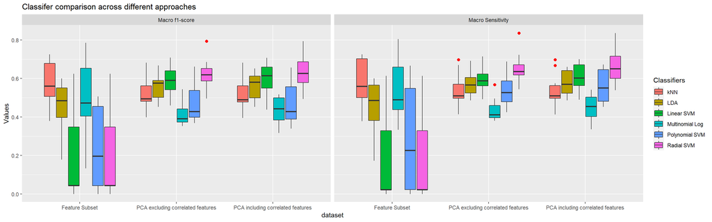

This boxplot shows the variability of performance i.e. macro weighted f1 score (left) and macro sensitivity (right) across various folds for different classifiers for the 3 approaches. In general feature subset does not seem like a good option for this dataset due it it’s huge variability across the folds. Performing PCA is giving better performance and less variability across folds for all classifiers. PCA performed after removing correlated features seems to be having less variability across various folds of data. kNN and multinomial log seems to be doing well with feature subsetting. Let us examine average of macro f1-scores. The code for this is in the appendix.

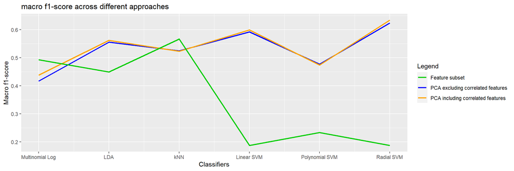

The above plot shows average of macro f1-score across all folds for various approached and classifiers. The average of macro f1-score over PCA including and excluding correlated features are almost similar but as per the previous plot the variability is less over PCA excluding correlated features. Hence we will not consider classification performed on PCA including correlated features. kNN and multinomial log have better performance when performed on subset of features than performed over principal components but the variation across various folds is large and also they are not better than Linear SVM and Radial SVM performed over principal components and hence we will also not consider results of feature subset. Linear SVM, Radial SVM classifiers performed on principal components excluding correlated features seems to be performing better with a macro f1-score of 0.59, 0.62. We will now optimize hyper parameters i.e. cost for linear SVM, cost and gamma for radial SVM.

### **Hyperparameter optimization**

We will perform steps for optimizing hyper parameters.

The below is the code for linear SVM hyper parameter optimization.

[figure not shown]

```r
fold <- createFolds(arrhythmia_labels, k=10) # apply 10-fold cross-validation
costval = seq(1,10,0.2) #Values of cost to be tested
for(cost in costval)
{
f1scores = c()
sens_Scores = c()
for(i in 1:length(fold)){
#Apply PCA on training dat
arrhythmia.pca <- prcomp(processed_arrhythmia_df_nolabels[-fold[[i]],-which(names(processed_arrhythmia_df_nolabels) %in% c(colums_to_drop))])
tot.var <- sum(arrhythmia.pca$sdev^2)
var.explained <- data.frame(pc = seq(1:ncol(processed_arrhythmia_df_nolabels[-fold[[i]],-which(names(processed_arrhythmia_df_nolabels) %in% c(colums_to_drop))])), var.explained  = arrhythmia.pca$sdev^2/tot.var )

cum_var.explained =c()
for (u in seq(nrow(var.explained)))
{cum_var.explained =  c(cum_var.explained,sum(var.explained[1:u,2])*100)}

#Identify number of PCs to be used for 95% variability
pctouse = min(which(cum_var.explained > 95))

#Oversample minor classes
oversampled_df = data.frame(arrhythmia.pca$x[,1:pctouse])
oversampled_df$class = arrhythmia_labels[-fold[[i]]]
all_exis_classes  = sort(unique(arrhythmia_labels))
for (eachminroclass in all_exis_classes[!all_exis_classes %in% 1])
{
balanceddata<-ovun.sample(class ~ ., data =subset(oversampled_df,class == eachminroclass | class == 1), method = "over",p=0.5)$data
oversampled_df = rbind(subset(balanceddata,class != 1),subset(oversampled_df,class != eachminroclass))
}
oversampled_df <- oversampled_df[sample(nrow(oversampled_df)),]  #Shuffling rows

#apply PCA on test data
arrhythmia.pcatest = predict(arrhythmia.pca,processed_arrhythmia_df_nolabels[fold[[i]],-which(names(processed_arrhythmia_df_nolabels) %in% c(colums_to_drop))])

svm.model1 <- svm(x = oversampled_df[,-which(colnames(oversampled_df) %in% c("class")),drop=FALSE], y = oversampled_df$class, kernel = "linear", type = "C-classification", cost = cost)
preds <- predict(svm.model1, newdata=data.frame(arrhythmia.pcatest[,1:pctouse]) )

f1score <- calcF1Scores(as.numeric(levels(preds))[preds],arrhythmia_labels[fold[[i]]]) #Calculate f1-score and recall on validation data
f1scores = c(f1scores,f1score[[1]])
}
knn.fone = c(knn.fone,mean(f1scores))
knn.sen = c(knn.sen,mean(sens_Scores))
}

#Store data for plotting
lin.plot.dat <- data.frame(values = c(unlist(knn.fone),unlist(knn.sen)),metric = rep(c("Macro f1-score","Macro Sensitivity"),each=length(costval)),k = rep(costval, times=2))
```

These plots indicate macro f1-score (left) and macro sensitivity (right) of validation dataset for Linear SVM performed on principal componets after excluding correalted features for various values of cost. Linear SVM seems to be performing better for cost = 3.2 as it has high macro f1-score and high macro sensitivity. The code for this is in appendix.

We will perform similar steps for optimizing hyperparamters for radial SVM, but we will repeat the process for various values of cost i.e. 100, 200 to 1000 and gamma i.e. 0.001,0.002 to 0.01. The code for this is available in appendix.

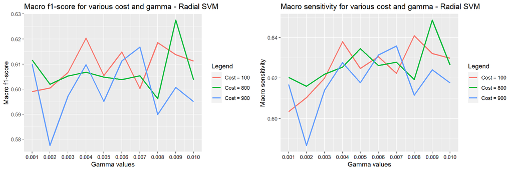

These plots indicate macro f1-score (left) and macro sensitivity (right) of validation dataset for radial SVM performed on principal componets after excluding correalted features for various values of cost and gamma. These plots are not the entire analysis but only a representation of required results. Radial SVM seems to be performing better for cost = 800 and gamma = 0.009. The code for this is available in appendix.

We will now compare Linear SVM, Radial SVM with default hyperparamters and with optimized hyperparameters. The code for this is available in appendix.

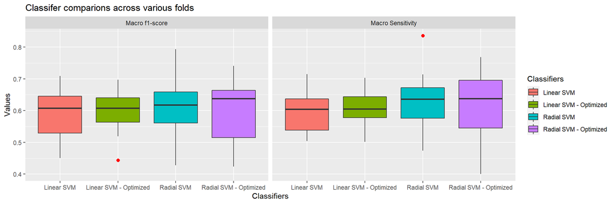

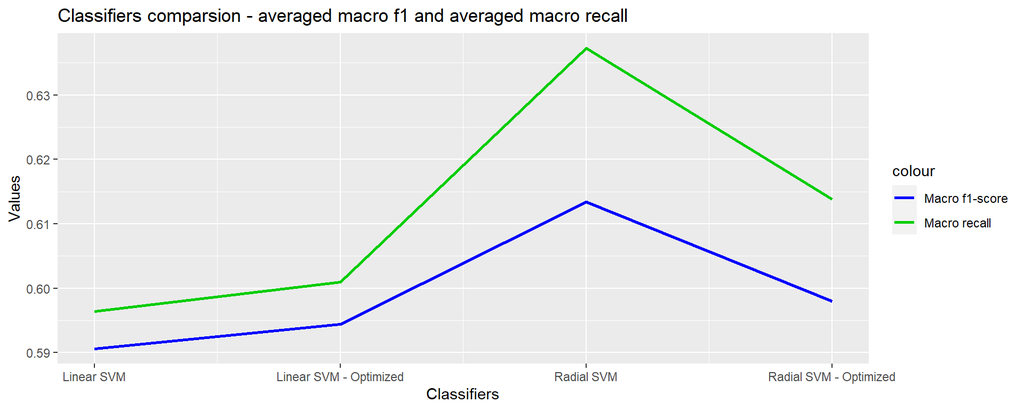

The line graph is a comparison of average of macro f1 and macro recall over different folds of data and this indicates that Radial SVM with default parameters has a better average macro f1 and better average macro recall over others i.e. 0.61, 0.63. The code for this is available in appendix.

Multi-class area under the roc curve for radial SVM with default paramters on validation dataset is 0.7471. This indicates the model is good in distinguishing between classes but is not perfect.

## **Conclusion**

The dataset also does not have samples for 3 of 16 classes and this is preventing our model to make more accurate predictions. The dataset should also include more samples for some classes so that our classifiers does not rely on oversampling techniques.

This can be good starting point for us to use this approach to reduce false alerts in the clinical areas and assist clinical staff but this needs some more work i.e. more gold standard data, more computation efficient environment to explore other strategies.

## **References**

Arrhythmia Data Set at: http://archive.ics.uci.edu/ml/datasets/Arrhythmia

Krzysztof, G 2019, Reducing False Arrhythmia Alarms at: https://www.ncbi.nlm.nih.gov/pmc/articles/PMC6479538/

Christopher, G 2019, Handling Multi-Class Imbalance at: https://towardsdatascience.com/multi-class-imbalance-154ef2b15816

## **Appendix**

The below is the code for creating histogram of labels.

```r
library(ggplot2)
ggplot(data = arrhythmia_df, aes(x = class)) +
  geom_histogram(
    data = subset(arrhythmia_df, class == 1),
    fill = "forestgreen",
    alpha = 0.8
  ) +
  geom_histogram(
    data = subset(arrhythmia_df, class != 1),
    fill = "firebrick",
    alpha = 0.8
  ) +
  ggtitle("Frequency of labels") +
  xlab("Class") + ylab("Count") +
  geom_text(
    stat = 'count',
    mapping = aes(label = paste(round((..count..) / sum(..count..) * 100
    ), "%", sep = "")),
    position = position_stack(vjust = 1.05),
    size = 4
  ) +
  scale_x_continuous(breaks = seq(0, max(arrhythmia_df$class), 1))  +
  theme_classic()
```

The below is the code for creating barplot of missing values.

```r
library(skimr)
summary_df = skim(arrhythmia_df) #We will use for missing values
missing_stats = data.frame(summary_df[summary_df$n_missing != 0, c("skim_variable", "n_missing")]) #Only fetch the missing values
colnames(missing_stats) = c("column_name", "no_of_missing")
missing_stats$percent_missing = paste(round(missing_stats$no_of_missing /
                                              nrow(arrhythmia_df) * 100), "%") #Percenttage calculation
library(ggplot2)
ggplot(data = missing_stats, aes(x = column_name, y = no_of_missing)) +
  geom_bar(stat = "identity", fill = "steelblue") +
  ggtitle("Missing observations") +
  xlab("Column Names") + ylab("Missing observations") + ylim(c(0, nrow(arrhythmia_df))) +
  geom_text(aes(label = percent_missing)) + theme_classic()
```

The below is the code for box plot of height and weight.

```r
require(gridExtra)
plot1 = ggplot(data = arrhythmia_df_nolabels, aes(x = Height)) +
  geom_boxplot(
    outlier.colour = "red",
    outlier.shape = 16,
    outlier.size = 2,
    notch = FALSE
  ) +  ggtitle("Spread of Height")
plot2 = ggplot(data = arrhythmia_df_nolabels, aes(x = Weight)) +
  geom_boxplot(
    outlier.colour = "red",
    outlier.shape = 16,
    outlier.size = 2,
    notch = FALSE
  ) +  ggtitle("Spread of Weight")
grid.arrange(plot1, plot2, ncol = 2)
```

The below is the code for box plot of V101,V201 and V301.

```r
#Side by side boxplot for similar features for better comparison
Columns_for_boxplot = c("V101", "V201", "V301")
wfdur_df = data.frame(rep(Columns_for_boxplot, times = nrow(arrhythmia_df)), as.vector(t(arrhythmia_df[, Columns_for_boxplot]))) #Creating dummy data frame for storing all 3 column values in one for boxplotting
colnames(wfdur_df) = c("Vx01", "Value")
ggplot(data = wfdur_df, aes(x = Value, y = Vx01)) +
  geom_boxplot(
    outlier.colour = "red",
    outlier.shape = 16,
    outlier.size = 2,
    notch = FALSE
  ) + ggtitle("Spread of V101,V201,V301") + xlab("Value") + theme(axis.text =
                                                                    element_text(size = 14),
                                                                  axis.title = element_text(size = 14))
```

The below is the code for box plot of DIII188 and DIII189.

```r
Columns_for_boxplot = c("DIII188", "DIII189")  #Side by side boxplot for similar features for better comparison
wfdur_df = data.frame(rep(Columns_for_boxplot, times = nrow(arrhythmia_df)), as.vector(t(arrhythmia_df[, Columns_for_boxplot]))) #Creating dummy data frame for storing all 2 column values in one for boxplotting
colnames(wfdur_df) = c("DIII18x", "Value")
ggplot(data = wfdur_df, aes(x = Value, y = DIII18x)) +
  geom_boxplot(
    outlier.colour = "red",
    outlier.shape = 16,
    outlier.size = 2,
    notch = FALSE
  ) + ggtitle("Spread of DIII188,DIII189") + xlab("Value") + theme(axis.text =
                                                                     element_text(size = 14),
                                                                   axis.title = element_text(size = 14))
```

The below is the code used for examining all remaining features.

```r
Columns_for_boxplot = c("Q_Wave", "R_Wave", "S_Wave")
wfdur_df = data.frame(rep(Columns_for_boxplot, times = nrow(arrhythmia_df)), as.vector(t(arrhythmia_df[, Columns_for_boxplot])))
colnames(wfdur_df) = c("WaveForm", "Value")
ggplot(data = wfdur_df, aes(x = Value, y = WaveForm)) +   geom_boxplot(
  outlier.colour = "red",
  outlier.shape = 16,
  outlier.size = 2,
  notch = FALSE
) + ggtitle("Spread of width") + xlab("Milli seconds")
#Can consider later
Columns_for_boxplot = c("R'_Wave", "S'_Wave", "Int_Def", "Rag_R_Nom")
wfdur_df = data.frame(rep(Columns_for_boxplot, times = nrow(arrhythmia_df)), as.vector(t(arrhythmia_df[, Columns_for_boxplot])))
colnames(wfdur_df) = c("WaveForm", "Value")
ggplot(data = wfdur_df, aes(x = Value, y = WaveForm)) +   geom_boxplot(
  outlier.colour = "red",
  outlier.shape = 16,
  outlier.size = 2,
  notch = FALSE
) + ggtitle("Spread of peaks after R") + xlab("Milli seconds")
Columns_for_boxplot = c("Diph_R_Nom",
                        "Rag_P_Nom",
                        "Diph_P_Nom",
                        "Rag_T_Nom",
                        "Diph_T_Nom")
wfdur_df = data.frame(rep(Columns_for_boxplot, times = nrow(arrhythmia_df)), as.vector(t(arrhythmia_df[, Columns_for_boxplot])))
colnames(wfdur_df) = c("WaveForm", "Value")
ggplot(data = wfdur_df, aes(x = Value, y = WaveForm)) +   geom_boxplot(
  outlier.colour = "red",
  outlier.shape = 16,
  outlier.size = 2,
  notch = FALSE
) + ggtitle("Spread of Norm") + xlab("Milli seconds")
Columns_for_boxplot = c(
  "DII00",
  "DII01",
  "DII02",
  "DII03",
  "DII04",
  "DII05",
  "DII06",
  "DII07",
  "DII08",
  "DII09",
  "DII10",
  "DII11",
  "DIII00",
  "DIII01",
  "DIII02",
  "DIII03",
  "DIII04",
  "DIII05",
  "DIII06",
  "DIII07",
  "DIII08",
  "DIII09",
  "DIII10",
  "DIII11"
)
wfdur_df = data.frame(rep(Columns_for_boxplot, times = nrow(arrhythmia_df)), as.vector(t(arrhythmia_df[, Columns_for_boxplot])))
colnames(wfdur_df) = c("WaveForm", "Value")
ggplot(data = wfdur_df, aes(x = Value, y = WaveForm)) +   geom_boxplot(
  outlier.colour = "red",
  outlier.shape = 16,
  outlier.size = 2,
  notch = FALSE
) + ggtitle("Spread of DII08 and others") + xlab("Milli seconds") + coord_flip() +  theme(axis.text =
                                                                                         element_text(size = 14),
                                                                                       axis.title = element_text(size = 14))
Columns_for_boxplot = c(
  "DII00",
  "DII01",
  "DII02",
  "DII03",
  "DII04",
  "DII05",
  "DII06",
  "DII07",
  "DII08",
  "DII09",
  "DII10",
  "DII11",
  "DIII00",
  "DIII01",
  "DIII02",
  "DIII03",
  "DIII04",
  "DIII05",
  "DIII06",
  "DIII07",
  "DIII08",
  "DIII09",
  "DIII10",
  "DIII11"
)
wfdur_df = data.frame(rep(Columns_for_boxplot, times = nrow(arrhythmia_df)), as.vector(t(arrhythmia_df[, Columns_for_boxplot])))
colnames(wfdur_df) = c("WaveForm", "Value")
Columns_for_boxplot = c(
  "AVR00",
  "AVR01",
  "AVR02",
  "AVR03",
  "AVR04",
  "AVR05",
  "AVR06",
  "AVR07",
  "AVR08",
  "AVR09",
  "AVR10",
  "AVR11",
  "AVL00",
  "AVL01",
  "AVL02",
  "AVL03",
  "AVL04",
  "AVL05",
  "AVL06",
  "AVL07",
  "AVL08",
  "AVL09",
  "AVL10",
  "AVL11"
)
wfdur_df = data.frame(rep(Columns_for_boxplot, times = nrow(arrhythmia_df)), as.vector(t(arrhythmia_df[, Columns_for_boxplot])))
colnames(wfdur_df) = c("WaveForm", "Value")
ggplot(data = wfdur_df, aes(x = Value, y = WaveForm)) +   geom_boxplot(
  outlier.colour = "red",
  outlier.shape = 16,
  outlier.size = 2,
  notch = FALSE
) + ggtitle("Spread of DII08 and others") + xlab("Milli seconds") + coord_flip() +  theme(axis.text =
                                                                                         element_text(size = 14),
                                                                                       axis.title = element_text(size = 14))
ggplot(data = wfdur_df, aes(x = Value, y = WaveForm)) +   geom_boxplot(
  outlier.colour = "red",
  outlier.shape = 16,
  outlier.size = 2,
  notch = FALSE
) + ggtitle("Spread of DII08 and others") + xlab("Milli seconds") + coord_flip() +  theme(axis.text =
                                                                                         element_text(size = 14),
                                                                                       axis.title = element_text(size = 14))
Columns_for_boxplot = c(
  "AVF00",
  "AVF01",
  "AVF02",
  "AVF03",
  "AVF04",
  "AVF05",
  "AVF06",
  "AVF07",
  "AVF08",
  "AVF09",
  "AVF10",
  "AVF11"
)
wfdur_df = data.frame(rep(Columns_for_boxplot, times = nrow(arrhythmia_df)), as.vector(t(arrhythmia_df[, Columns_for_boxplot])))
colnames(wfdur_df) = c("WaveForm", "Value")
ggplot(data = wfdur_df, aes(x = Value, y = WaveForm)) +   geom_boxplot(
  outlier.colour = "red",
  outlier.shape = 16,
  outlier.size = 2,
  notch = FALSE
) + ggtitle("Spread of DII08 and others") + xlab("Milli seconds") + coord_flip()
Columns_for_boxplot = c(
  "V100",
  "V101",
  "V102",
  "V103",
  "V104",
  "V105",
  "V106",
  "V107",
  "V108",
  "V109",
  "V110",
  "V111",
  "V200",
  "V201",
  "V202",
  "V203",
  "V204",
  "V205",
  "V206",
  "V207",
  "V208",
  "V209",
  "V210",
  "V211"
)
wfdur_df = data.frame(rep(Columns_for_boxplot, times = nrow(arrhythmia_df)), as.vector(t(arrhythmia_df[, Columns_for_boxplot])))
colnames(wfdur_df) = c("WaveForm", "Value")
ggplot(data = wfdur_df, aes(x = Value, y = WaveForm)) +   geom_boxplot(
  outlier.colour = "red",
  outlier.shape = 16,
  outlier.size = 2,
  notch = FALSE
) + ggtitle("Spread of .............") + xlab("Milli seconds") + coord_flip() +  theme(axis.text =
                                                                                         element_text(size = 14),
                                                                                       axis.title = element_text(size = 14))
Columns_for_boxplot = c(
  "V300",
  "V301",
  "V302",
  "V303",
  "V304",
  "V305",
  "V306",
  "V307",
  "V308",
  "V309",
  "V310",
  "V311",
  "V400",
  "V401",
  "V402",
  "V403",
  "V404",
  "V405",
  "V406",
  "V407",
  "V408",
  "V409",
  "V410",
  "V411"
)
wfdur_df = data.frame(rep(Columns_for_boxplot, times = nrow(arrhythmia_df)), as.vector(t(arrhythmia_df[, Columns_for_boxplot])))
colnames(wfdur_df) = c("WaveForm", "Value")
Columns_for_boxplot = c("V101", "V201", "V301")
wfdur_df = data.frame(rep(Columns_for_boxplot, times = nrow(arrhythmia_df)), as.vector(t(arrhythmia_df[, Columns_for_boxplot]))) #Creating dummy data frame for storing all 3 column values in one for boxplotting
colnames(wfdur_df) = c("Vx01", "Value")
ggplot(data = wfdur_df, aes(x = Value, y = Vx01)) +
  geom_boxplot(
    outlier.colour = "red",
    outlier.shape = 16,
    outlier.size = 2,
    notch = FALSE
  ) + ggtitle("Spread of V101,V201,V301") + xlab("Value") + theme(axis.text =
                                                                    element_text(size = 14),
                                                                  axis.title = element_text(size = 14))
ggplot(data = wfdur_df, aes(x = Value, y = WaveForm)) +   geom_boxplot(
  outlier.colour = "red",
  outlier.shape = 16,
  outlier.size = 2,
  notch = FALSE
) + ggtitle("Spread of DII08 and others") + xlab("Milli seconds") + coord_flip() +  theme(axis.text =
                                                                                         element_text(size = 14),
                                                                                       axis.title = element_text(size = 14))
Columns_for_boxplot = c(
  "V500",
  "V501",
  "V502",
  "V503",
  "V504",
  "V505",
  "V506",
  "V507",
  "V508",
  "V509",
  "V510",
  "V511",
  "V600",
  "V601",
  "V602",
  "V603",
  "V604",
  "V605",
  "V606",
  "V607",
  "V608",
  "V609",
  "V610",
  "V611"
)
wfdur_df = data.frame(rep(Columns_for_boxplot, times = nrow(arrhythmia_df)), as.vector(t(arrhythmia_df[, Columns_for_boxplot])))
colnames(wfdur_df) = c("WaveForm", "Value")
ggplot(data = wfdur_df, aes(x = Value, y = WaveForm)) +   geom_boxplot(
  outlier.colour = "red",
  outlier.shape = 16,
  outlier.size = 2,
  notch = FALSE
) + ggtitle("Spread of DII08 and others") + xlab("Milli seconds") + coord_flip() +  theme(axis.text =
                                                                                         element_text(size = 14),
                                                                                       axis.title = element_text(size = 14))
Columns_for_boxplot = c(
  "JJ_Wave",
  "Amp_Q_Wave",
  "Amp_R_Wave",
  "Amp_S_Wave",
  "R_Prime_Wave",
  "S_Prime_Wave",
  "P_Wave",
  "T_Wave"
)
wfdur_df = data.frame(rep(Columns_for_boxplot, times = nrow(arrhythmia_df)), as.vector(t(arrhythmia_df[, Columns_for_boxplot])))
colnames(wfdur_df) = c("WaveForm", "Value")
ggplot(data = wfdur_df, aes(x = Value, y = WaveForm)) +   geom_boxplot(
  outlier.colour = "red",
  outlier.shape = 16,
  outlier.size = 2,
  notch = FALSE
) + ggtitle("Spread of DII08 and others") + xlab("Milli seconds") + coord_flip() +  theme(axis.text =
                                                                                         element_text(size = 14),
                                                                                       axis.title = element_text(size = 14))
Columns_for_boxplot = c(
  "QRSA",
  "QRSTA",
  "DII170",
  "DII171",
  "DII172",
  "DII173",
  "DII174",
  "DII175",
  "DII176",
  "DII177",
  "DII178",
  "DII179"
)
wfdur_df = data.frame(rep(Columns_for_boxplot, times = nrow(arrhythmia_df)), as.vector(t(arrhythmia_df[, Columns_for_boxplot])))
colnames(wfdur_df) = c("WaveForm", "Value")
ggplot(data = wfdur_df, aes(x = Value, y = WaveForm)) +   geom_boxplot(
  outlier.colour = "red",
  outlier.shape = 16,
  outlier.size = 2,
  notch = FALSE
) + ggtitle("Spread of DII08 and others") + xlab("Milli seconds") + coord_flip() +  theme(axis.text =
                                                                                         element_text(size = 14),
                                                                                       axis.title = element_text(size = 14))
Columns_for_boxplot = c(
  "DIII180",
  "DIII181",
  "DIII182",
  "DIII183",
  "DIII184",
  "DIII185",
  "DIII186",
  "DIII187",
  "DIII188",
  "DIII189"
)
wfdur_df = data.frame(rep(Columns_for_boxplot, times = nrow(arrhythmia_df)), as.vector(t(arrhythmia_df[, Columns_for_boxplot])))
colnames(wfdur_df) = c("WaveForm", "Value")
ggplot(data = wfdur_df, aes(x = Value, y = WaveForm)) +   geom_boxplot(
  outlier.colour = "red",
  outlier.shape = 16,
  outlier.size = 2,
  notch = FALSE
) + ggtitle("Spread of DII08 and others") + xlab("Milli seconds") + coord_flip() +  theme(axis.text =
                                                                                         element_text(size = 14),
                                                                                       axis.title = element_text(size = 14))
Columns_for_boxplot = c(
  "AVR190",
  "AVR191",
  "AVR192",
  "AVR193",
  "AVR194",
  "AVR195",
  "AVR196",
  "AVR197",
  "AVR198",
  "AVR199"
)
wfdur_df = data.frame(rep(Columns_for_boxplot, times = nrow(arrhythmia_df)), as.vector(t(arrhythmia_df[, Columns_for_boxplot])))
colnames(wfdur_df) = c("WaveForm", "Value")
ggplot(data = wfdur_df, aes(x = Value, y = WaveForm)) +   geom_boxplot(
  outlier.colour = "red",
  outlier.shape = 16,
  outlier.size = 2,
  notch = FALSE
) + ggtitle("Spread of DII08 and others") + xlab("Milli seconds") + coord_flip() +  theme(axis.text =
                                                                                         element_text(size = 14),
                                                                                       axis.title = element_text(size = 14))
Columns_for_boxplot = c(
  "AVL200",
  "AVL201",
  "AVL202",
  "AVL203",
  "AVL204",
  "AVL205",
  "AVL206",
  "AVL207",
  "AVL208",
  "AVL209"
)
wfdur_df = data.frame(rep(Columns_for_boxplot, times = nrow(arrhythmia_df)), as.vector(t(arrhythmia_df[, Columns_for_boxplot])))
```

```r
colnames(wfdur_df) = c("WaveForm", "Value")
ggplot(data = wfdur_df, aes(x = Value, y = WaveForm)) +   geom_boxplot(
  outlier.colour = "red",
  outlier.shape = 16,
  outlier.size = 2,
  notch = FALSE
) + ggtitle("Spread of DII08 and others") + xlab("Milli seconds") + coord_flip() +  theme(axis.text =
                                                                                         element_text(size = 14),
                                                                                       axis.title = element_text(size = 14))
Columns_for_boxplot = c(
  "AVF210",
  "AVF211",
  "AVF212",
  "AVF213",
  "AVF214",
  "AVF215",
  "AVF216",
  "AVF217",
  "AVF218",
  "AVF219"
)
wfdur_df = data.frame(rep(Columns_for_boxplot, times = nrow(arrhythmia_df)), as.vector(t(arrhythmia_df[, Columns_for_boxplot])))
colnames(wfdur_df) = c("WaveForm", "Value")
ggplot(data = wfdur_df, aes(x = Value, y = WaveForm)) +   geom_boxplot(
  outlier.colour = "red",
  outlier.shape = 16,
  outlier.size = 2,
  notch = FALSE
) + ggtitle("Spread of DII08 and others") + xlab("Milli seconds") + coord_flip() +  theme(axis.text =
                                                                                         element_text(size = 14),
                                                                                       axis.title = element_text(size = 14))
Columns_for_boxplot = c(
  "V1220",
  "V1221",
  "V1222",
  "V1223",
  "V1224",
  "V1225",
  "V1226",
  "V1227",
  "V1228",
  "V1229",
  "V2230",
  "V2231",
  "V2232",
  "V2233",
  "V2234",
  "V2235",
  "V2236",
  "V2237",
  "V2238",
  "V2239"
)
wfdur_df = data.frame(rep(Columns_for_boxplot, times = nrow(arrhythmia_df)), as.vector(t(arrhythmia_df[, Columns_for_boxplot])))
colnames(wfdur_df) = c("WaveForm", "Value")
ggplot(data = wfdur_df, aes(x = Value, y = WaveForm)) +   geom_boxplot(
  outlier.colour = "red",
  outlier.shape = 16,
  outlier.size = 2,
  notch = FALSE
) + ggtitle("Spread of DII08 and others") + xlab("Milli seconds") + coord_flip() +  theme(axis.text =
                                                                                         element_text(size = 14),
                                                                                       axis.title = element_text(size = 14))
Columns_for_boxplot = c(
  "V3240",
  "V3241",
  "V3242",
  "V3243",
  "V3244",
  "V3245",
  "V3246",
  "V3247",
  "V3248",
  "V3249",
  "V4250",
  "V4251",
  "V4252",
  "V4253",
  "V4254",
  "V4255",
  "V4256",
  "V4257",
  "V4258",
  "V4259"
)
wfdur_df = data.frame(rep(Columns_for_boxplot, times = nrow(arrhythmia_df)), as.vector(t(arrhythmia_df[, Columns_for_boxplot])))
colnames(wfdur_df) = c("WaveForm", "Value")
ggplot(data = wfdur_df, aes(x = Value, y = WaveForm)) +   geom_boxplot(
  outlier.colour = "red",
  outlier.shape = 16,
  outlier.size = 2,
  notch = FALSE
) + ggtitle("Spread of DII08 and others") + xlab("Milli seconds") + coord_flip() +  theme(axis.text =
                                                                                         element_text(size = 14),
                                                                                       axis.title = element_text(size = 14))
Columns_for_boxplot = c(
  "V5260",
  "V5261",
  "V5262",
  "V5263",
  "V5264",
  "V5265",
  "V5266",
  "V5267",
  "V5268",
  "V5269",
  "V6270",
  "V6271",
  "V6272",
  "V6273",
  "V6274",
  "V6275",
  "V6276",
  "V6277",
  "V6278",
  "V6279"
)
wfdur_df = data.frame(rep(Columns_for_boxplot, times = nrow(arrhythmia_df)), as.vector(t(arrhythmia_df[, Columns_for_boxplot])))
colnames(wfdur_df) = c("WaveForm", "Value")
ggplot(data = wfdur_df, aes(x = Value, y = WaveForm)) +   geom_boxplot(
  outlier.colour = "red",
  outlier.shape = 16,
  outlier.size = 2,
  notch = FALSE
) + ggtitle("Spread of DII08 and others") + xlab("Milli seconds") + coord_flip() +  theme(axis.text =
                                                                                         element_text(size = 14),
                                                                                       axis.title = element_text(size = 14))
```

The below is the code for visualizing continous correlated ECG features

```r
#The belo function is to create a smooting line in the ggpairs plot
regline_fn <- function(data, mapping, ...) {
  p <- ggplot(data = data, mapping = mapping) + geom_point() +
    geom_smooth(method = loess,
                fill = "red",
                color = "red",...) +
    geom_smooth(method = lm,
                fill = "blue",
                color = "blue",...)
  p
}
require(gridExtra)
plot1 = ggpairs(processed_arrhythmia_df_nolabels[, c(related_numerical_cols[1, 1], related_numerical_cols[1, 2])],
                lower = list(continuous = regline_fn))
plot2 = ggpairs(processed_arrhythmia_df_nolabels[, c(related_numerical_cols[2, 1], related_numerical_cols[2, 2])],
                lower = list(continuous = regline_fn))
plot3 = ggpairs(processed_arrhythmia_df_nolabels[, c(related_numerical_cols[3, 1], related_numerical_cols[3, 2])],
                lower = list(continuous = regline_fn))
plot4 = ggpairs(processed_arrhythmia_df_nolabels[, c(related_numerical_cols[4, 1], related_numerical_cols[4, 2])],
                lower = list(continuous = regline_fn))
grid.arrange(
  grid.grabExpr(print(plot1)),
  grid.grabExpr(print(plot2)),
  grid.grabExpr(print(plot3)),
  grid.grabExpr(print(plot4)),
  ncol = 4
)
```

The below is the Code for performing PCA on dataset with correlated features and without correlated features.

```r
arrhythmia.pca <- prcomp(processed_arrhythmia_df_nolabels) #PCA of dataset with correlated columns
tot.var <- sum(arrhythmia.pca$sdev ^ 2)
var.explained <-  data.frame(pc = seq(1:278),
             var.explained  = arrhythmia.pca$sdev ^ 2 / tot.var)
cum_var.explained = c()
for (i in seq(nrow(var.explained)))
{
  cum_var.explained =  c(cum_var.explained, sum(var.explained[1:i, 2]) * 100)  #Calculating cumulative variance
}

processed_arrhythmia_df_nolabels2 = processed_arrhythmia_df_nolabels[, -which(names(arrhythmia_df_nolabels) %in% colums_to_drop)] #Drop correlated columns
arrhythmia.pca2 <- prcomp(processed_arrhythmia_df_nolabels2) #PCA of dataset without correlated columns
tot.var <- sum(arrhythmia.pca2$sdev ^ 2)
var.explained <-
  data.frame(pc = seq(1:ncol(processed_arrhythmia_df_nolabels2)),
             var.explained  = arrhythmia.pca2$sdev ^ 2 / tot.var)
cum_var.explained2 = c()
for (i in seq(nrow(var.explained)))
{
  cum_var.explained2 =  c(cum_var.explained2, sum(var.explained[1:i, 2]) * 100) #Calculating cumulative variance
}
```

The below is the code for the plot showing cumulative variance explained by PCA

```r
cum_var.explained_df <- data.frame(pc = seq(1:ncol(processed_arrhythmia_df_nolabels)),  cum_var.explained  =  cum_var.explained)

pca1plot = ggplot(cum_var.explained_df[1:45, ], aes(pc, cum_var.explained)) + geom_bar(stat = "identity") + ggtitle("PCA on dataset with correlated features")  +
  geom_hline(aes(yintercept = 95), colour = "red") + geom_text(aes(0, 95, label = "95% variability", vjust = 1), size = 3) +
  labs(y = "% of cum. variance exp.") +
  scale_x_continuous(breaks = seq(0, 45), "Principal Components")  +
  theme_classic()

cum_var.explained_df2 <- data.frame(pc = seq(1:ncol(processed_arrhythmia_df_nolabels2)),  cum_var.explained2  =  cum_var.explained2)

pca2plot = ggplot(cum_var.explained_df2[1:45, ], aes(pc, cum_var.explained2)) + geom_bar(stat = "identity") + ggtitle("PCA on dataset without correlated features") +
  geom_hline(aes(yintercept = 95), colour = "red") + geom_text(aes(0, 95, label = "95% variability", vjust = 1), size = 3)  +
  labs(y = "% of cum. variance exp.") +
  scale_x_continuous(breaks = seq(0, 45), "Principal Components")  +
  theme_classic()

require(gridExtra)
grid.arrange(pca1plot, pca2plot, nrow = 2)
```

The below code is for feature subset for linear SVM.

```r
selectFeature <-
  function(train, test, cls.train, cls.test, features) {
    ## identify a feature to be selected
    current.best.fone <- -Inf
    selected.i <- NULL
    for (i in 1:ncol(train)) {
      current.f <- colnames(train)[i]
      if (!current.f %in% features) {
        subfeatures_df_train = data.frame(class = cls.train)
        subfeatures_df_test = data.frame(class = cls.test)
        allcols = c(features, current.f)
        for (eachcol in allcols)
        {
          subfeatures_df_train[, eachcol] = train[, eachcol]
          subfeatures_df_test[, eachcol] = test[, eachcol]
        }
        oversampled_df = subfeatures_df_train
        all_exis_classes  = sort(unique(arrhythmia_labels))

        for (eachminroclass in all_exis_classes[!all_exis_classes %in% 1])
        {
          testdf = subset(oversampled_df, class == eachminroclass |
                            class == 1)
          balanceddata <-
            ovun.sample(
              class ~ .,
              data = get("testdf", sys.frame(1)),
              method = "over",
              p = 0.5
            )$data
          oversampled_df = rbind(
            subset(balanceddata, class != 1),
            subset(oversampled_df, class != eachminroclass)
          )
        }
        linsvm.model1 <-
          svm(
            x = oversampled_df[, -which(colnames(oversampled_df) %in% c("class")), drop =
                                 FALSE],
            y = oversampled_df[, "class"],
            kernel = "linear",
            type = "C-classification"
          )
        preds <-
          predict(linsvm.model1, newdata = subfeatures_df_test[, -which(colnames(subfeatures_df_test) %in% c("class")), drop =
                                                                 FALSE])
        f1score <- calcF1Scores(as.numeric(levels(preds))[preds], cls.test)
        test.fone = round(f1score[[1]], 3)
        if (test.fone >  current.best.fone) {
          current.best.fone <- test.fone
          selected.i <- colnames(train)[i]
        }
      }
    }
    return(list(selected.i, current.best.fone))
  }

library(caret)
set.seed(1)
inTrain <- createDataPartition(arrhythmia_labels, p = .6)[[1]]
allFeatures <- colnames(processed_arrhythmia_df_nolabels)

train <- processed_arrhythmia_df_nolabels[inTrain, ]
test  <- processed_arrhythmia_df_nolabels[-inTrain, ]
cls.train <- arrhythmia_labels[inTrain]
cls.test <- arrhythmia_labels[-inTrain]

features <- NULL
fone_scores = NULL
# select the 1 to 30 best features using a wrapper classifier
for (j in 1:30) {
  featureoutput <-
    selectFeature(train, test, cls.train, cls.test, features)
  features <- c(features, featureoutput[[1]])
  fone_scores = c(fone_scores, featureoutput[[2]])
}
```

The below code is for feature subset for radial SVM.

```r
selectFeature <-
  function(train, test, cls.train, cls.test, features) {
    ## identify a feature to be selected
    current.best.fone <- -Inf
    selected.i <- NULL
    for (i in 1:ncol(train)) {
      current.f <- colnames(train)[i]
      if (!current.f %in% features) {
        subfeatures_df_train = data.frame(class = cls.train)
        subfeatures_df_test = data.frame(class = cls.test)
        allcols = c(features, current.f)
        for (eachcol in allcols)
        {
          subfeatures_df_train[, eachcol] = train[, eachcol]
          subfeatures_df_test[, eachcol] = test[, eachcol]
        }

        oversampled_df = subfeatures_df_train
        all_exis_classes  = sort(unique(arrhythmia_labels))
        for (eachminroclass in all_exis_classes[!all_exis_classes %in% 1])
        {
          testdf = subset(oversampled_df, class == eachminroclass |
                            class == 1)
          balanceddata <-
            ovun.sample(
              class ~ .,
              data = get("testdf", sys.frame(1)),
              method = "over",
              p = 0.5
            )$data
          oversampled_df = rbind(
            subset(balanceddata, class != 1),
            subset(oversampled_df, class != eachminroclass)
          )
        }

        radial.model1 <-
          svm(
            x = oversampled_df[, -which(colnames(oversampled_df) %in% c("class")), drop =
                                 FALSE],
            y = oversampled_df[, "class"],
            kernel = "radial",
            type = "C-classification"
          )
        preds <-
          predict(radial.model1, newdata = subfeatures_df_test[, -which(colnames(subfeatures_df_test) %in% c("class")), drop =
                                                                 FALSE])

        f1score <- calcF1Scores(as.numeric(levels(preds))[preds], cls.test)
        test.fone = round(f1score[[1]], 3)
        #test.fone
        if (test.fone >  current.best.fone) {
          current.best.fone <- test.fone
          #fone_of_best = modelval.fone
          selected.i <- colnames(train)[i]
        }
      }
    }
    return(list(selected.i, current.best.fone))
  }

library(caret)
set.seed(1)
inTrain <- createDataPartition(arrhythmia_labels, p = .6)[[1]]
allFeatures <- colnames(processed_arrhythmia_df_nolabels)

train <- processed_arrhythmia_df_nolabels[inTrain, ]
test  <- processed_arrhythmia_df_nolabels[-inTrain, ]
cls.train <- arrhythmia_labels[inTrain]
cls.test <- arrhythmia_labels[-inTrain]

features <- NULL
fone_scores = NULL
for (j in 1:20) {
  featureoutput <-
    selectFeature(train, test, cls.train, cls.test, features)
  features <- c(features, featureoutput[[1]])
  fone_scores = c(fone_scores, featureoutput[[2]])
}
```

The below code is for feature subset for polynomial SVM.

```r
selectFeature <-
  function(train, test, cls.train, cls.test, features) {
    current.best.fone <- -Inf
    selected.i <- NULL
    for (i in 1:ncol(train)) {
      current.f <- colnames(train)[i]
      if (!current.f %in% features) {
        subfeatures_df_train = data.frame(class = cls.train)
        subfeatures_df_test = data.frame(class = cls.test)
        allcols = c(features, current.f)
        for (eachcol in allcols)
        {
          subfeatures_df_train[, eachcol] = train[, eachcol]
          subfeatures_df_test[, eachcol] = test[, eachcol]
        }

        polynomial.model1 <-
          svm(
            x = subfeatures_df_train[, -which(colnames(subfeatures_df_train) %in% c("class")), drop =
                                       FALSE],
            y = subfeatures_df_train[, "class"],
            kernel = "polynomial",
            type = "C-classification",
            degree = 2
          )
        preds <-
          predict(polynomial.model1, newdata = subfeatures_df_test[, -which(colnames(subfeatures_df_test) %in% c("class")), drop =
                                                                     FALSE])

        f1score <- calcF1Scores(as.numeric(levels(preds))[preds], cls.test)

        test.fone = round(f1score[[1]], 3)
        if (test.fone >  current.best.fone) {
          current.best.fone <- test.fone
          selected.i <- colnames(train)[i]
        }
      }
    }
    return(list(selected.i, current.best.fone))
  }

library(caret)
set.seed(1)
inTrain <- createDataPartition(arrhythmia_labels, p = .6)[[1]]
allFeatures <- colnames(processed_arrhythmia_df_nolabels)
train <- processed_arrhythmia_df_nolabels[inTrain, ]
oversampled_df = train
oversampled_df$class = arrhythmia_labels[inTrain]
all_exis_classes  = sort(unique(arrhythmia_labels))
for (eachminroclass in all_exis_classes[!all_exis_classes %in% 1])
{
  balanceddata <-
    ovun.sample(
      class ~ .,
      data = subset(oversampled_df, class == eachminroclass |
                      class == 1),
      method = "over",
      p = 0.5
    )$data
  oversampled_df = rbind(subset(balanceddata, class != 1),
                         subset(oversampled_df, class != eachminroclass))
}

train = oversampled_df[, -which(colnames(oversampled_df) %in% c("class")), drop =
                         FALSE]
test  <- processed_arrhythmia_df_nolabels[-inTrain, ]
cls.train <- oversampled_df[, "class"]
cls.test <- arrhythmia_labels[-inTrain]

features = NULL
fone_scores = NULL

for (j in 1:30) {
  featureoutput <-
    selectFeature(train, test, cls.train, cls.test, features)
  features <- c(features, featureoutput[[1]])
  fone_scores = c(fone_scores, featureoutput[[2]])
}
```

The below code is for feature subset for Multinomial Log.

```r
selectFeature <-
  function(train, test, cls.train, cls.test, features) {
    ## identify a feature to be selected
    current.best.fone <- -Inf
    selected.i <- NULL
    for (i in 1:ncol(train)) {
      current.f <- colnames(train)[i]
      if (!current.f %in% features) {
        subfeatures_df_train = data.frame(class = cls.train)
        subfeatures_df_test = data.frame(class = cls.test)
        allcols = c(features, current.f)
        for (eachcol in allcols)
        {
          subfeatures_df_train[, eachcol] = train[, eachcol]
          subfeatures_df_test[, eachcol] = test[, eachcol]
        }

        multinomlogmodel <-
          multinom(class ~ ., data = subfeatures_df_train, trace = FALSE)
        preds = predict(multinomlogmodel, newdata = subfeatures_df_test[, -which(colnames(subfeatures_df_test) %in% c("class")), drop =
                                                                          FALSE])
        f1score <- calcF1Scores(as.numeric(levels(preds))[preds], cls.test)
        test.fone = round(f1score[[1]], 3)
        if (test.fone >  current.best.fone) {
          current.best.fone <- test.fone
          selected.i <- colnames(train)[i]
        }
      }
    }
    return(list(selected.i, current.best.fone))
  }

library(caret)
set.seed(1)
inTrain <- createDataPartition(arrhythmia_labels, p = .6)[[1]]
allFeatures <- colnames(processed_arrhythmia_df_nolabels)
train <- processed_arrhythmia_df_nolabels[inTrain, ]
oversampled_df = train
oversampled_df$class = arrhythmia_labels[inTrain]
all_exis_classes  = sort(unique(arrhythmia_labels))
for (eachminroclass in all_exis_classes[!all_exis_classes %in% 1])
{
  balanceddata <-
    ovun.sample(
      class ~ .,
      data = subset(oversampled_df, class == eachminroclass |
                      class == 1),
      method = "over",
      p = 0.5
    )$data
  oversampled_df = rbind(subset(balanceddata, class != 1),
                         subset(oversampled_df, class != eachminroclass))
}

train = oversampled_df[, -which(colnames(oversampled_df) %in% c("class")), drop =
                         FALSE]
test  <- processed_arrhythmia_df_nolabels[-inTrain, ]
cls.train <- oversampled_df[, "class"]
cls.test <- arrhythmia_labels[-inTrain]

features = NULL
fone_scores = NULL
for (j in 1:20) {
  featureoutput <-
    selectFeature(train, test, cls.train, cls.test, features)
  features <- c(features, featureoutput[[1]])
  fone_scores = c(fone_scores, featureoutput[[2]])
}
```

The below code is for feature subset for LDA.

```r
selectFeature <-
  function(train, test, cls.train, cls.test, features) {
    ## identify a feature to be selected
    current.best.fone <- -Inf
    selected.i <- NULL
    for (i in 1:ncol(train)) {
      current.f <- colnames(train)[i]
      if (!current.f %in% features) {
        subfeatures_df_train = data.frame(class = cls.train)
        subfeatures_df_test = data.frame(class = cls.test)
        allcols = c(features, current.f)
        for (eachcol in allcols)
        {
          subfeatures_df_train[, eachcol] = train[, eachcol]
          subfeatures_df_test[, eachcol] = test[, eachcol]
        }
        flag <- TRUE
        tryCatch({
          lda.model <- MASS::lda(class ~ ., data = subfeatures_df_train)
        }, error = function(e) {
          flag <<- FALSE
        })

        if (!flag) {
          next
        }
        ldapreds = predict(lda.model, newdata = subfeatures_df_test[, -which(colnames(subfeatures_df_test) %in% c("class")), drop =
                                                                      FALSE])$class
        f1score <-
          calcF1Scores(as.numeric(levels(ldapreds))[ldapreds], cls.test)
        test.fone = round(f1score[[1]], 3)
        if (test.fone >  current.best.fone) {
          current.best.fone <- test.fone
          selected.i <- colnames(train)[i]
        }
      }
    }
    return(list(selected.i, current.best.fone))
  }

library(caret)
set.seed(1)
inTrain <- createDataPartition(arrhythmia_labels, p = .6)[[1]]
allFeatures <- colnames(processed_arrhythmia_df_nolabels)
train <- processed_arrhythmia_df_nolabels[inTrain, ]
oversampled_df = train
oversampled_df$class = arrhythmia_labels[inTrain]
all_exis_classes  = sort(unique(arrhythmia_labels))
for (eachminroclass in all_exis_classes[!all_exis_classes %in% 1])
{
  balanceddata <-
    ovun.sample(
      class ~ .,
      data = subset(oversampled_df, class == eachminroclass |
                      class == 1),
      method = "over",
      p = 0.5
    )$data
  oversampled_df = rbind(subset(balanceddata, class != 1),
                         subset(oversampled_df, class != eachminroclass))
}

train = oversampled_df[, -which(colnames(oversampled_df) %in% c("class")), drop =
                         FALSE]
test  <- processed_arrhythmia_df_nolabels[-inTrain, ]
cls.train <- oversampled_df[, "class"]
cls.test <- arrhythmia_labels[-inTrain]

features = NULL
fone_scores = NULL
for (j in 1:30) {
  featureoutput <-
    selectFeature(train, test, cls.train, cls.test, features)
  features <- c(features, featureoutput[[1]])
  fone_scores = c(fone_scores, featureoutput[[2]])
}
```

The below code is to visualize feature subset performance in various subplots .

```r
p1= ggplot(data=knn_featuresubset_metrics ,aes(x=index,y=macrof1))+geom_line(data=knn_featuresubset_metrics ,aes(x=index,y=macrof1) ,size = 1)+     labs(title="kNN", x ="Features", y = "Macro f1-score")+ scale_x_continuous(breaks =knn_featuresubset_metrics$index, labels=knn_featuresubset_metrics$Features) + theme(axis.text.x = element_text(angle = 90, hjust = 1))

p2= ggplot(data=linsvm_featuresubset_metrics ,aes(x=index,y=macrof1))+geom_line(data=linsvm_featuresubset_metrics ,aes(x=index,y=macrof1) ,size = 1)+ labs(title="Linear SVM", x ="Features", y = "Macro f1-score")+ scale_x_continuous(breaks =linsvm_featuresubset_metrics$index, labels=linsvm_featuresubset_metrics$Features) + theme(axis.text.x = element_text(angle = 90, hjust = 1))

p3= ggplot(data=radsvm_featuresubset_metrics,aes(x=index,y=macrof1))+geom_line(data=radsvm_featuresubset_metrics ,aes(x=index,y=macrof1) ,size = 1)+ labs(title="Radial SVM", x ="Features", y = "Macro f1-score")+ scale_x_continuous(breaks =radsvm_featuresubset_metrics$index, labels=radsvm_featuresubset_metrics$Features) + theme(axis.text.x = element_text(angle = 90, hjust = 1))

p4= ggplot(data=multilog_featuresubset_metrics ,aes(x=index,y=macrof1))+geom_line(data=multilog_featuresubset_metrics ,aes(x=index,y=macrof1) ,size = 1)+ labs(title="Multinomial Log", x ="Features", y = "Macro f1-score")+ scale_x_continuous(breaks =multilog_featuresubset_metrics$index, labels=multilog_featuresubset_metrics$Features) + theme(axis.text.x = element_text(angle = 90, hjust = 1))

p5= ggplot(data=lda_featuresubset_metrics ,aes(x=index,y=macrof1))+geom_line(data=lda_featuresubset_metrics ,aes(x=index,y=macrof1) ,size = 1)+ labs(title="LDA", x ="Features", y = "Macro f1-score")+ scale_x_continuous(breaks =lda_featuresubset_metrics$index, labels=lda_featuresubset_metrics$Features) + theme(axis.text.x = element_text(angle = 90, hjust = 1))

p6= ggplot(data=polysvm_featuresubset_metrics ,aes(x=index,y=macrof1))+geom_line(data=polysvm_featuresubset_metrics ,aes(x=index,y=macrof1) ,size = 1)+ labs(title="Polynomial SVM", x ="Features", y = "Macro f1-score")+ scale_x_continuous(breaks =polysvm_featuresubset_metrics$index, labels=polysvm_featuresubset_metrics$Features) + theme(axis.text.x = element_text(angle = 90, hjust = 1))

require(gridExtra)

grid.arrange(p1,p2,p3,p4,p5,p6, ncol=3,nrow=2)
```

```r
set.seed(1)
fold <- createFolds(arrhythmia_labels, k = 10) # apply 10-fold cross-validation
tmp2f1knn = tmp2f1linsvm = tmp2f1ploy = tmp2f1radc = tmp2f1lda = tmp2f1log = c()
tmp2recaknn = tmp2recalinsvm = tmp2recaploy = tmp2recaradc = tmp2recalda = tmp2recalog = c()

for (i in 1:length(fold)) {
  arrhythmia.pca <-
    prcomp(processed_arrhythmia_df_nolabels[-fold[[i]], -which(names(processed_arrhythmia_df_nolabels) %in% c(colums_to_drop))]) #apply PCA on training data without correlated features
  tot.var <- sum(arrhythmia.pca$sdev ^ 2)
  var.explained <- data.frame(pc = seq(1:ncol(processed_arrhythmia_df_nolabels[-fold[[i]], -which(names(processed_arrhythmia_df_nolabels) %in% c(colums_to_drop))])),var.explained  = arrhythmia.pca$sdev ^ 2 / tot.var)

  cum_var.explained = c()
  for (u in seq(nrow(var.explained)))
  {
    cum_var.explained =  c(cum_var.explained, sum(var.explained[1:u, 2]) * 100)
  }
  #identify minimum PCs for 95% variability

  pctouse = min(which(cum_var.explained > 95))

  #Oversample minor classes in training data
  oversampled_df = data.frame(arrhythmia.pca$x[, 1:pctouse])
  oversampled_df$class = arrhythmia_labels[-fold[[i]]]
  all_exis_classes  = sort(unique(arrhythmia_labels))

  for (eachminroclass in all_exis_classes[!all_exis_classes %in% 1])
  {
    balanceddata <-
      ovun.sample(
        class ~ .,
        data = subset(oversampled_df, class == eachminroclass |
                        class == 1),
        method = "over",
        p = 0.5
      )$data

    oversampled_df = rbind(subset(balanceddata, class != 1),
                           subset(oversampled_df, class != eachminroclass))
  }
  oversampled_df <- oversampled_df[sample(nrow(oversampled_df)), ]  #Shuffling rows

  #apply PCA on validation data
  arrhythmia.pcatest = predict(arrhythmia.pca, processed_arrhythmia_df_nolabels[fold[[i]], -which(names(processed_arrhythmia_df_nolabels) %in% c(colums_to_drop))])

  #Train classifiers
  preds <- knn(oversampled_df[, -which(colnames(oversampled_df) %in% c("class")), drop =FALSE],data.frame(arrhythmia.pcatest[, 1:pctouse]),oversampled_df$class)#, k=1)
  f1score <- calcF1Scores(as.numeric(levels(preds))[preds], arrhythmia_labels[fold[[i]]])
  tmp2f1knn = c(tmp2f1knn, f1score[[1]])
  tmp2recaknn = c(tmp2recaknn, f1score[[2]])

  linsvm.model1 <- svm(x = oversampled_df[, -which(colnames(oversampled_df) %in% c("class")), drop =FALSE],y = oversampled_df$class,kernel = "linear",type = "C-classification")
  preds <- predict(linsvm.model1, newdata = data.frame(arrhythmia.pcatest[, 1:pctouse]))
  f1score <- calcF1Scores(as.numeric(levels(preds))[preds], arrhythmia_labels[fold[[i]]])
  tmp2f1linsvm = c(tmp2f1linsvm, f1score[[1]])
  tmp2recalinsvm = c(tmp2recalinsvm, f1score[[2]])


  polysvm.model1 <- svm(x = oversampled_df[, -which(colnames(oversampled_df) %in% c("class")), drop =FALSE],y = oversampled_df$class,kernel = "polynomial",type = "C-classification")
  preds <- predict(polysvm.model1, newdata = data.frame(arrhythmia.pcatest[, 1:pctouse]))
  f1score <- calcF1Scores(as.numeric(levels(preds))[preds], arrhythmia_labels[fold[[i]]])
  tmp2f1ploy = c(tmp2f1ploy, f1score[[1]])
  tmp2recaploy = c(tmp2recaploy, f1score[[2]])

  radsvm.model1 <- svm(x = oversampled_df[, -which(colnames(oversampled_df) %in% c("class")), drop =FALSE],y = oversampled_df$class,kernel = "radial",type = "C-classification")
  preds <- predict(radsvm.model1, newdata = data.frame(arrhythmia.pcatest[, 1:pctouse]))
  f1score <- calcF1Scores(as.numeric(levels(preds))[preds], arrhythmia_labels[fold[[i]]])
  tmp2f1radc = c(tmp2f1radc, f1score[[1]])
  tmp2recaradc = c(tmp2recaradc, f1score[[2]])

  lda.model <- MASS::lda(class ~ ., data = oversampled_df)
  preds = predict(lda.model, newdata = data.frame(arrhythmia.pcatest[, 1:pctouse]))$class
  f1score <- calcF1Scores(as.numeric(levels(preds))[preds], arrhythmia_labels[fold[[i]]])
  tmp2f1lda = c(tmp2f1lda, f1score[[1]])
  tmp2recalda = c(tmp2recalda, f1score[[2]])

  multinomlogmodel <- multinom(class ~ ., data = oversampled_df, trace = FALSE)
  preds = predict(multinomlogmodel, newdata = data.frame(arrhythmia.pcatest[, 1:pctouse]))
  f1score <- calcF1Scores(as.numeric(levels(preds))[preds], arrhythmia_labels[fold[[i]]])
  tmp2f1log = c(tmp2f1log, f1score[[1]])
  tmp2recalog = c(tmp2recalog, f1score[[2]])

}

fone.val = c(mean(tmp2f1log ),mean(tmp2f1lda),mean(tmp2f1knn),mean(tmp2f1linsvm),mean(tmp2f1ploy),mean(tmp2f1radc))
recall.val = c(mean(tmp2recalog ),mean(tmp2recalda),mean(tmp2recaknn),mean(tmp2recalinsvm),mean(tmp2recaploy),mean(tmp2recaradc))

plot_df95pca2 = data.frame(index= seq(1:6),fone=fone.val,recall=recall.val,algo= c("Multinomial Log","LDA","kNN","Linear SVM","Polynomial SVM","Radial SVM"))
    ggplot(data=plot_df95pca2 ,aes(x=index,y=fone))+geom_line(data=plot_df95pca2 ,aes(x=index,y=fone,color="f1-score") ,size = 1)+geom_line(data=plot_df95pca2 ,aes(x=index,y=recall,color="recall") ,size = 1)+labs(title="F1-score various algo - 95% var - without correlated columns")+ scale_x_continuous(breaks =plot_df95pca2$index, labels=plot_df95pca2$algo) +scale_color_manual(values = c('f1-score' = 'blue',  'recall' = 'green'))

boxplot_df_pca295= data.frame("Values"=c(tmp2recalog,tmp2recalda,tmp2recaknn,tmp2recalinsvm,tmp2recaploy,tmp2recaradc,tmp2f1log,tmp2f1lda,tmp2f1knn,tmp2f1linsvm,tmp2f1ploy,tmp2f1radc),"Classifiers"=rep(rep(c("Multinomial Log","LDA","kNN","Linear SVM","Polynomial SVM","Radial SVM"),each =10),times=2),"Metric"=rep(c("Macro Sensitivity","Macro f1-score"),each=60))

 ggplot(data=boxplot_df_pca295, aes(x=Classifiers,y=Values, fill=Classifiers)) +   geom_boxplot(outlier.colour="red", outlier.shape=16,outlier.size=2, notch=FALSE) + ggtitle("Classifer Evaluation  - 95% var - without correlated columns") + facet_wrap(~Metric)
```

The below code is for comparing classifers across different approaches via boxplot.

```r
newdf = rbind(boxplot_df_pca95,boxplot_df_pca295,boxplot_df_subset)
newdf$dataset = rep(c("PCA including correlated features","PCA excluding correlated features","Feature Subset"),each=120)

 ggplot(data=newdf, aes(x=dataset,y=Values, fill=Classifiers)) +   geom_boxplot(outlier.colour="red", outlier.shape=16,outlier.size=2, notch=FALSE) + ggtitle("Classifer comparison across different approaches") + facet_wrap(~Metric)
```

The below code is for comparing classifers across different approaches via line plot.

```r
ggplot(data=plot_df95pca2 ,aes(x=index,y=fone))+geom_line(data=plot_df95pca2 ,aes(x=index,y=fone,color="PCA excluding correlated features") ,size = 1)+geom_line(data=plot_df95pca ,aes(x=index,y=fone,color="PCA including correlated features") ,size = 1)+geom_line(data=plot_dfsubset ,aes(x=index,y=fone,color="Feature subset") ,size = 1)+   labs(title="macro f1-score across different approaches", x ="Classifiers", y = "Macro f1-score")+ scale_x_continuous(breaks =plot_df95pca$index, labels=plot_df95pca$algo) +scale_color_manual(name = "Legend",values = c('Feature subset' = 'green3','PCA excluding correlated features' = 'blue','PCA including correlated features' = 'orange'))
```

The below code is for visualizing lineavr SVM performance for different values of cost - hyperparameter optimization

```r
lin.plot.dat = subset(lin.plot.dat,k <5.1)
ggplot(lin.plot.dat) + geom_line(aes(x = k, y = values, fill= metric))+ scale_x_continuous(breaks = lin.plot.dat$k)+    labs(title="macro f1-score and macro sensitivty for different cost values - Linear SVM", x ="Cost", y = "Value") + facet_wrap(~metric)
```

The below code is for hyper paramter optimization of radial SVM.

```r
fold <- createFolds(arrhythmia_labels, k=10)

knn.sen = knn.fone = c()
knn.fnr.k = c()

gamma_Values = seq(0.001,0.01,0.001)#c(0.001,0.01,0.1, 1, 10, 100)
cost_values =  seq(100,1000,100) #seq(10)

gamma_cost_values = cbind(rep(gamma_Values, times = length(cost_values)),rep(cost_values, each = length(gamma_Values)))

for (idx in seq(nrow(gamma_cost_values)))
{
 knn.TP <- knn.TN <- knn.FP <- knn.FN <- c()
lda.TP <- lda.TN <- lda.FP <- lda.FN <- c()
f1scores = c()
sens_Scores = c()
for(i in 1:length(fold)){

arrhythmia.pca <- prcomp(processed_arrhythmia_df_nolabels[-fold[[i]],-which(names(processed_arrhythmia_df_nolabels) %in% c(colums_to_drop))])
tot.var <- sum(arrhythmia.pca$sdev^2)
var.explained <- data.frame(pc = seq(1:ncol(processed_arrhythmia_df_nolabels[-fold[[i]],-which(names(processed_arrhythmia_df_nolabels) %in% c(colums_to_drop))])), var.explained  = arrhythmia.pca$sdev^2/tot.var )
cum_var.explained =c()
for (u in seq(nrow(var.explained)))
{cum_var.explained =  c(cum_var.explained,sum(var.explained[1:u,2])*100)}

pctouse = min(which(cum_var.explained > 95))
oversampled_df = data.frame(arrhythmia.pca$x[,1:pctouse])
oversampled_df$class = arrhythmia_labels[-fold[[i]]]
all_exis_classes  = sort(unique(arrhythmia_labels))
for (eachminroclass in all_exis_classes[!all_exis_classes %in% 1])
{
balanceddata<-ovun.sample(class ~ ., data =subset(oversampled_df,class == eachminroclass | class == 1), method = "over",p=0.5)$data
oversampled_df = rbind(subset(balanceddata,class != 1),subset(oversampled_df,class != eachminroclass))
}
oversampled_df <- oversampled_df[sample(nrow(oversampled_df)),]  #Shuffling rows
arrhythmia.pcatest = predict(arrhythmia.pca,processed_arrhythmia_df_nolabels[fold[[i]],-which(names(processed_arrhythmia_df_nolabels) %in% c(colums_to_drop))])

 svm.model1 <- svm(x = oversampled_df[,-which(colnames(oversampled_df) %in% c("class")),drop=FALSE], y = oversampled_df$class, kernel = "radial", type = "C-classification", cost = gamma_cost_values[idx,2],gamma = gamma_cost_values[idx,1])
    preds <- predict(svm.model1, newdata=data.frame(arrhythmia.pcatest[,1:pctouse]) )
    f1score <- calcF1Scores(as.numeric(levels(preds))[preds],arrhythmia_labels[fold[[i]]])
  f1scores = c(f1scores,f1score[[1]])
    sens_Scores = c(sens_Scores,f1score[[2]])
}

knn.fone = c(knn.fone,mean(f1scores))
knn.sen = c(knn.sen,mean(sens_Scores))

}
radvm.plot.dat <- data.frame(values = c(unlist(knn.fone),unlist(knn.sen)),metric = rep(c("Macro f1-score","Macro sensitivity"),each=length(seq(nrow(gamma_cost_values)))),gamma = rep(gamma_cost_values[,1], times=2),   cost = rep(gamma_cost_values[,2], times=2))
```

The below code is for visualizing radial SVM performance for different values of cost and gamma - hyperparameter optimization

```r
t1 = ggplot(data = subset(radvm.plot.dat , metric == "Macro f1-score" &
                            cost == 100) ,
            aes(x = gamma, y = values)) + geom_line(
              data = subset(radvm.plot.dat , metric == "Macro f1-score" &
                              cost == 100) ,
              aes(x = gamma, y = values, color = "Cost = 100") ,
              size = 1
            ) + geom_line(
              data = subset(radvm.plot.dat , metric == "Macro f1-score" &
                              cost == 800) ,
              aes(x = gamma, y = values, color = "Cost = 800") ,
              size = 1
            ) + geom_line(
              data = subset(radvm.plot.dat , metric == "Macro f1-score" &
                              cost == 900) ,
              aes(x = gamma, y = values, color = "Cost = 900") ,
              size = 1
            ) + labs(title = "Macro f1-score for various cost and gamma - Radial SVM", x =
                       "Gamma values", y = "Macro f1-score") + scale_x_continuous(breaks = radvm.plot.dat$gamma) +
  scale_color_discrete(name = "Legend")
t2 = ggplot(
  data = subset(radvm.plot.dat , metric == "Macro sensitivity" &
                  cost == 100) ,
  aes(x = gamma, y = values)
) + geom_line(
  data = subset(radvm.plot.dat , metric == "Macro sensitivity" &
                  cost == 100) ,
  aes(x = gamma, y = values, color = "Cost = 100") ,
  size = 1
) + geom_line(
  data = subset(radvm.plot.dat , metric == "Macro sensitivity" &
                  cost == 800) ,
  aes(x = gamma, y = values, color = "Cost = 800") ,
  size = 1
) + geom_line(
  data = subset(radvm.plot.dat , metric == "Macro sensitivity" &
                  cost == 900) ,
  aes(x = gamma, y = values, color = "Cost = 900") ,
  size = 1
) + labs(title = "Macro sensitivity for various cost and gamma - Radial SVM", x =
           "Gamma values", y = "Macro sensitivity") + scale_x_continuous(breaks = radvm.plot.dat$gamma) +
  scale_color_discrete(name = "Legend")
require(gridExtra)
grid.arrange(t1, t2, ncol = 2)
```

The below code is for training and comparing, linear SVM, radial SVM with default and optimized parameters and also for visualizing the results via box plot.

```r
fold <- createFolds(arrhythmia_labels, k=10)
# apply 10-fold cross-validation

tmp2f1knn =tmp2f1linsvm =tmp2f1linsvmop= tmp2f1ploy = tmp2f1radc =tmp2f1radcop= tmp2f1lda = tmp2f1log = c()
tmp2recaknn =tmp2recalinsvm =tmp2recalinsvmop= tmp2recaploy = tmp2recaradc =tmp2recaradcop= tmp2recalda = tmp2recalog = c()

for(i in 1:length(fold)){

arrhythmia.pca <- prcomp(processed_arrhythmia_df_nolabels[-fold[[i]],-which(names(processed_arrhythmia_df_nolabels) %in% c(colums_to_drop))])
tot.var <- sum(arrhythmia.pca$sdev^2)
var.explained <- data.frame(pc = seq(1:ncol(processed_arrhythmia_df_nolabels[-fold[[i]],-which(names(processed_arrhythmia_df_nolabels) %in% c(colums_to_drop))])), var.explained  = arrhythmia.pca$sdev^2/tot.var )

cum_var.explained =c()
for (u in seq(nrow(var.explained)))
{cum_var.explained =  c(cum_var.explained,sum(var.explained[1:u,2])*100)}

#Identifying the number of principal components to explain 95% var
pctouse = min(which(cum_var.explained > 95))

#Over sampling minor classes
oversampled_df = data.frame(arrhythmia.pca$x[,1:pctouse])
oversampled_df$class = arrhythmia_labels[-fold[[i]]]
all_exis_classes  = sort(unique(arrhythmia_labels))

for (eachminroclass in all_exis_classes[!all_exis_classes %in% 1])
{
balanceddata<-ovun.sample(class ~ ., data =subset(oversampled_df,class == eachminroclass | class == 1), method = "over",p=0.5)$data
oversampled_df = rbind(subset(balanceddata,class != 1),subset(oversampled_df,class != eachminroclass))
}
oversampled_df <- oversampled_df[sample(nrow(oversampled_df)),]  #Shuffling rows

#apply PCA on test
arrhythmia.pcatest = predict(arrhythmia.pca,processed_arrhythmia_df_nolabels[fold[[i]],-which(names(processed_arrhythmia_df_nolabels) %in% c(colums_to_drop))])

linsvm.model1 <- svm(x = oversampled_df[,-which(colnames(oversampled_df) %in% c("class")),drop=FALSE], y = oversampled_df$class, kernel = "linear", type = "C-classification")#, cost = 2.5)
preds <- predict(linsvm.model1, newdata=data.frame(arrhythmia.pcatest[,1:pctouse]))
f1score <- calcF1Scores(as.numeric(levels(preds))[preds],arrhythmia_labels[fold[[i]]])
tmp2f1linsvm = c(tmp2f1linsvm,f1score[[1]])
tmp2recalinsvm = c(tmp2recalinsvm,f1score[[2]])


linsvm.model1 <- svm(x = oversampled_df[,-which(colnames(oversampled_df) %in% c("class")),drop=FALSE], y = oversampled_df$class, kernel = "linear", type = "C-classification", cost = 3.2)
preds <- predict(linsvm.model1, newdata=data.frame(arrhythmia.pcatest[,1:pctouse]))
f1score <- calcF1Scores(as.numeric(levels(preds))[preds],arrhythmia_labels[fold[[i]]])
tmp2f1linsvmop = c(tmp2f1linsvmop,f1score[[1]])
tmp2recalinsvmop = c(tmp2recalinsvmop,f1score[[2]])

radsvm.model1 <- svm(x = oversampled_df[,-which(colnames(oversampled_df) %in% c("class")),drop=FALSE], y = oversampled_df$class, kernel = "radial", type = "C-classification")#, cost = 500,gamma = 0.009)
preds <- predict(radsvm.model1, newdata=data.frame(arrhythmia.pcatest[,1:pctouse]))
f1score <- calcF1Scores(as.numeric(levels(preds))[preds],arrhythmia_labels[fold[[i]]])
tmp2f1radc = c(tmp2f1radc,f1score[[1]])
tmp2recaradc = c(tmp2recaradc,f1score[[2]])

radsvm.model1 <- svm(x = oversampled_df[,-which(colnames(oversampled_df) %in% c("class")),drop=FALSE], y = oversampled_df$class, kernel = "radial", type = "C-classification",cost = 800,gamma = 0.009)
preds <- predict(radsvm.model1, newdata=data.frame(arrhythmia.pcatest[,1:pctouse]))
f1score <- calcF1Scores(as.numeric(levels(preds))[preds],arrhythmia_labels[fold[[i]]])
tmp2f1radcop = c(tmp2f1radcop,f1score[[1]])
tmp2recaradcop = c(tmp2recaradcop,f1score[[2]])
}

fone.val = c(mean(tmp2f1linsvm),mean(tmp2f1linsvmop),mean(tmp2f1radc),mean(tmp2f1radcop))
recall.val = c(mean(tmp2recalinsvm),mean(tmp2recalinsvmop),mean(tmp2recaradc),mean(tmp2recaradcop))

plot_df95pca2opc = data.frame(index= seq(1:4),fone=fone.val,recall=recall.val,algo= c("Linear SVM","Linear SVM - Optimized","Radial SVM","Radial SVM - Optimized"))
boxplot_df95pca2opc= data.frame("Values"=c(tmp2recalinsvm,tmp2recalinsvmop,tmp2recaradc,tmp2recaradcop,tmp2f1linsvm,tmp2f1linsvmop,tmp2f1radc,tmp2f1radcop),"Classifiers"=rep(rep(c("Linear SVM","Linear SVM - Optimized","Radial SVM","Radial SVM - Optimized"),each =10),times=2),"Metric"=rep(c("Macro Sensitivity","Macro f1-score"),each=40))

ggplot(data=boxplot_df95pca2opc, aes(x=Classifiers,y=Values, fill=Classifiers)) +   geom_boxplot(outlier.colour="red", outlier.shape=16,outlier.size=2, notch=FALSE) + ggtitle("Classifer comparions across various folds") + facet_wrap(~Metric)
```

The below code is for line graph to compare classifiers with default and optimized parameters

```r
ggplot(data=plot_df95pca2opc ,aes(x=index,y=fone))+geom_line(data=plot_df95pca2opc ,aes(x=index,y=fone,color="Macro f1-score") ,size = 1)+geom_line(data=plot_df95pca2opc ,aes(x=index,y=recall,color="Macro recall") ,size = 1)+labs(title="Classifiers comparsion - averaged macro f1 and averaged macro recall", x ="Classifiers", y = "Values")+ scale_x_continuous(breaks =plot_df95pca2opc$index, labels=plot_df95pca2opc$algo) +scale_color_manual(values = c('Macro f1-score' = 'blue',  'Macro recall' = 'green3'))
```

The below code is for calculating ROC of the curve

```r
library(caret)
set.seed(1)

#Split data into traning and validatio data set
inTrain <- createDataPartition(arrhythmia_labels, p = .6)[[1]]
train <- processed_arrhythmia_df_nolabels[ inTrain,-which(names(processed_arrhythmia_df_nolabels) %in% c(colums_to_drop))]
test  <- processed_arrhythmia_df_nolabels[-inTrain,-which(names(processed_arrhythmia_df_nolabels) %in% c(colums_to_drop))]
cls.train <- arrhythmia_labels[inTrain]
cls.test <- arrhythmia_labels[-inTrain]

#apply PCA on training dataset
arrhythmia.pca <- prcomp(train)
tot.var <- sum(arrhythmia.pca$sdev^2)
var.explained <- data.frame(pc = seq(1:ncol(processed_arrhythmia_df_nolabels[-fold[[i]],-which(names(processed_arrhythmia_df_nolabels) %in% c(colums_to_drop))])), var.explained  = arrhythmia.pca$sdev^2/tot.var )

cum_var.explained =c()
for (u in seq(nrow(var.explained)))
{cum_var.explained =  c(cum_var.explained,sum(var.explained[1:u,2])*100)}

#Identif number of PCs to use to explain 95% variability
pctouse = min(which(cum_var.explained > 95))

oversampled_df = data.frame(arrhythmia.pca$x[,1:pctouse])
oversampled_df$class = cls.train
all_exis_classes  = sort(unique(arrhythmia_labels))
for (eachminroclass in all_exis_classes[!all_exis_classes %in% 1])
{
balanceddata<-ovun.sample(class ~ ., data =subset(oversampled_df,class == eachminroclass | class == 1), method = "over",p=0.5)$data
oversampled_df = rbind(subset(balanceddata,class != 1),subset(oversampled_df,class != eachminroclass))
}
oversampled_df <- oversampled_df[sample(nrow(oversampled_df)),]  #Shuffling rows
arrhythmia.pcatest = predict(arrhythmia.pca, test)


radsvm.model1 <- svm(x = oversampled_df[,-which(colnames(oversampled_df) %in% c("class")),drop=FALSE], y = oversampled_df$class, kernel = "radial", type = "C-classification")
#Calculate predictions on validation data
preds <- predict(radsvm.model1, newdata=data.frame(arrhythmia.pcatest[,1:pctouse]))

#Multiclass ROC under the curve calculation
library(pROC)
y_pred<-as.ordered(preds)
auc <- multiclass.roc(cls.test, y_pred)
print(auc(auc))
```